# Mirror reversal VS Rotation: Comparing motor adaptation and de novo learning

Raphael Gastrock

# Overview

This document discusses results for the tablet and online experiments. We also provide a more in depth analysis of the date here, and show additional figures and statistics.

# Set up the R enviornment

We have written code that pre-processes the data, plots figures, and runs statistical tests. Import the sources below:

```r
source('ana/shared.R')
#tablet experiment scripts
source('ana/ordereffects.R')
source('ana/learningRates.R')
source('ana/exponentialandstepModel.R')
source('ana/individualDataCheck.R')
source('ana/rae.R')
source('ana/RTandMT.R')
source('ana/pathlength.R')
#online experiment scripts
source('ana/controlmir.R')
source('ana/controlmirgen.R')
source('ana/su&fa2020online.R')
source('ana/qualtricsdata.R')
source('ana/mironline_fa2020.R')
source('ana/mirgeneralization_fa2020.R')
```

# Study 1: Tablet experiment results

For the tablet experiment, half of the participants (N = 16) were simply told to compensate for the cursor moving differently during perturbed reaches, and the other half (N = 16) were instructed about the nature of each perturbation and was given a strategy to counter for it. We focus on the non-instructed participants for most of the analyses, as we only wanted to observe the effects of instructions on initial learning in each perturbation for the instructed participants.

## Order Effects

Given that we implemented a within-subjects design for the tablet experiment, we first test whether learning one perturbation has an effect on learning the other. We also test for any effects in learning, depending on which axis each perturbation was experienced and the target locations relative to the perturbation axis.

### Perturbation order

#### Rotation

For perturbation order, we expect that learning in each perturbation should not affect the other, regardless of which perturbation the participant experienced first.

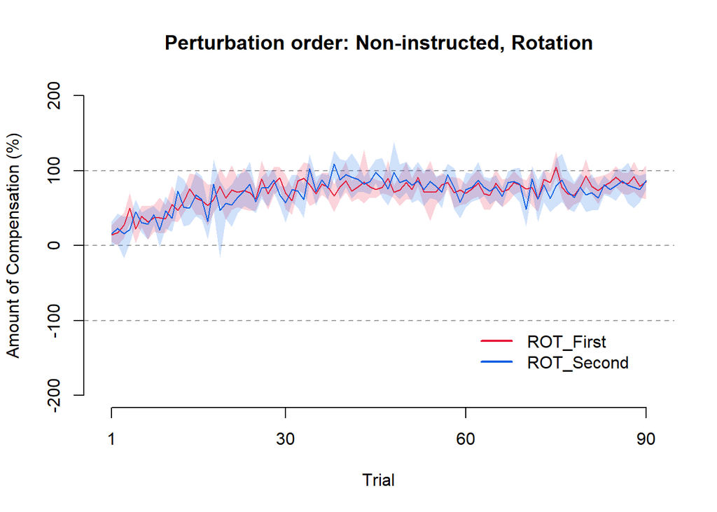

```r
plotNIROTOrderEffects()
```

For non-instructed participants, the percentage of compensation did not differ regardless of whether the rotation perturbation was experienced before or after mirror reversed perturbed reaches.

To quantify these comparisons between conditions better, we fit an exponential decay function that allowed us to measure learning rates and learning asymptotes. For perturbation order, we fit the exponential function to participants that either experienced the rotation before or after mirror reversed reaches.

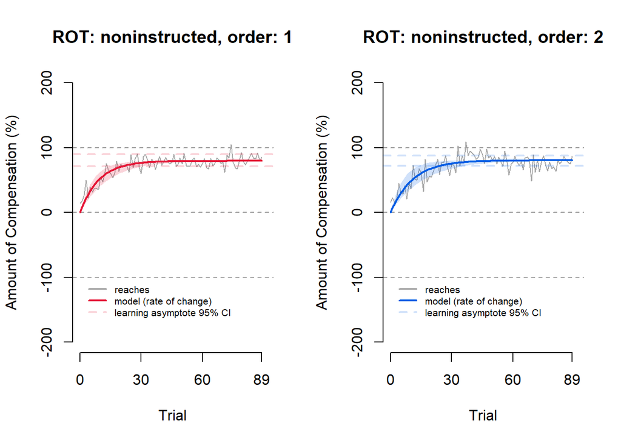

```r
plotROTOrderEffectsModel(group='noninstructed')
```

We then conducted t-tests to compare the learning rates and asymptotes between the two order conditions. Both frequentist and Bayesian tests are reported below.

```r
getLambdaOrderEffectsTTest(perturbation='ROT')
```

```
## Frequentist t-test (perturbation: ROT, condition: first vs. second):
##
##  Welch Two Sample t-test
##
## data:  subdat1 and subdat2
## t = -0.61244, df = 9.6387, p-value = 0.5544
## alternative hypothesis: true difference in means is not equal to 0
## 95 percent confidence interval:
##  -0.1935460  0.1104204
## sample estimates:
## mean of x mean of y
## 0.1137463 0.1553091
##
## Bayesian t-test (perturbation: ROT, condition: first vs. second):
## Bayes factor analysis
## --------------
## [1] Alt., r=0.707 : 0.4855399 ±0%
##
## Against denominator:
##   Null, mu1-mu2 = 0
## ---
## Bayes factor type: BFindepSample, JZS
```

```r
getAsymptoteOrderEffectsTTest(perturbation='ROT')
```

```
## Frequentist t-test (perturbation: ROT, condition: first vs. second):
##
##  Welch Two Sample t-test
##
## data:  subdat1 and subdat2
## t = -0.10034, df = 13.759, p-value = 0.9215
## alternative hypothesis: true difference in means is not equal to 0
## 95 percent confidence interval:
##  -14.73630  13.42118
## sample estimates:
## mean of x mean of y
##  81.30748  81.96503
##
## Bayesian t-test (perturbation: ROT, condition: first vs. second):
## Bayes factor analysis
## --------------
## [1] Alt., r=0.707 : 0.4290593 ±0%
##
## Against denominator:
##   Null, mu1-mu2 = 0
## ---
## Bayes factor type: BFindepSample, JZS
```

The tests confirmed that learning rates and learning asymptote did not differ regardless of whether the rotation was experienced before or after the other perturbation.

#### Mirror reversal

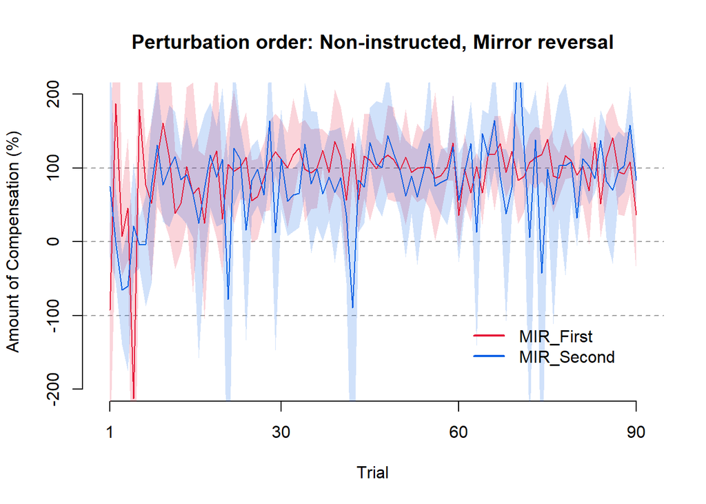

```r
plotNIMIROrderEffects()
```

For the mirror reversed perturbed reaches, we also do not find differences depending on the order that they experienced the perturbation. However, note that the percentages of compensation have larger variability compared to those in the rotation perturbation.

We fit the same exponential decay function to both conditions and conducted t-tests to compare learning rates and asymptotes between perturbation order conditions.

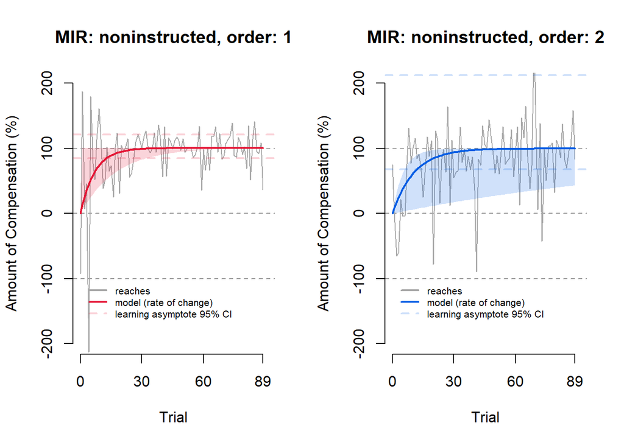

```r
plotMIROrderEffectsModel(groups='noninstructed')
```

We did not find any differences in learning rates and asymptotes between the mirror perturbation order conditions.

```r
getLambdaOrderEffectsTTest(perturbation='MIR')
```

```
## Frequentist t-test (perturbation: MIR, condition: first vs. second):
##
##  Welch Two Sample t-test
##
## data:  subdat1 and subdat2
## t = 1.0222, df = 8.0209, p-value = 0.3365
## alternative hypothesis: true difference in means is not equal to 0
## 95 percent confidence interval:
##  -0.1615243  0.4189405
## sample estimates:
## mean of x mean of y
## 0.2549276 0.1262195
##
## Bayesian t-test (perturbation: MIR, condition: first vs. second):
## Bayes factor analysis
## --------------
## [1] Alt., r=0.707 : 0.6055607 ±0%
##
## Against denominator:
##   Null, mu1-mu2 = 0
## ---
## Bayes factor type: BFindepSample, JZS
```

```r
getAsymptoteOrderEffectsTTest(perturbation='MIR')
```

```
## Frequentist t-test (perturbation: MIR, condition: first vs. second):
##
##  Welch Two Sample t-test
##
## data:  subdat1 and subdat2
## t = -1.436, df = 7.6622, p-value = 0.1905
## alternative hypothesis: true difference in means is not equal to 0
## 95 percent confidence interval:
##  -221.17018   52.22542
## sample estimates:
## mean of x mean of y
##  108.1419  192.6143
##
## Bayesian t-test (perturbation: MIR, condition: first vs. second):
## Bayes factor analysis
## --------------
## [1] Alt., r=0.707 : 0.835469 ±0%
##
## Against denominator:
##   Null, mu1-mu2 = 0
## ---
## Bayes factor type: BFindepSample, JZS
```

##### Model comparisons

Since the mirror reversal data had more variability, we wanted to investigate whether different functions will fit the data better. For some participants, compensation seemed to immediately become better after a few trials. That is, it seemed like they figured things out after a certain trial, and suddenly started to perform better. The nature of such a performance resembled a logistic or step function. Therefore, in addition to the exponential decay function, we also fit both step and logistic functions to the rotation and mirror reversed data for each participant.

For the exponential decay function we get two parameters: lambda for the learning rate, and N0 for the asymptote. For the step function, instead of a learning rate, we get a step parameter to indicate where the change occurs. We also get an asymptote parameter. For the logistic function we get three parameters: x0 (the steepest part of the logistic function), k (the inverse of the steepness of the logistic function), and L (the scale of the function, which starts at 0 (at -infinity) and reaches L at infinity).

After fitting each function to each participant’s data, we also calculate mean squared errors (MSE) between each function and the data. The parameters and MSEs for the rotation perturbation are shown below. Each row will correspond to one participant.

```r
read.csv('data/pilot/ROT_noninstructed_MSE_ordereffects.csv')
```

```
##    step asymptote  mse_step     lambda        N0  mse_expl         x0
## 1    12  72.98683  785.9078 0.05839083  81.57260  676.9233  12.552785
## 2     4  81.04288  456.9556 0.09788714  88.71477  252.5075   7.983897
## 3    12  60.44318  653.8266 0.09629438  62.55975  612.8795  10.666315
## 4     4  94.78372  361.9691 0.29441731  96.06407  310.4976   1.637205
## 5     4  70.74633  539.9778 0.11071178  76.33250  411.5146   5.026782
## 6    12  62.28616  881.3983 0.04072276  77.20361  671.5597  18.329900
## 7    12 101.79969 1774.4218 0.12128606 102.46256 1784.0515  10.396347
## 8     4  59.19791  483.4178 0.09026025  65.54994  354.8889   8.010550
## 9     4  71.36746  532.5357 0.04565858  89.73700  261.1401  16.116850
## 10   12  82.19301  614.3897 0.12774811  82.17503  652.5935  10.367659
## 11   12  83.50160 1034.1659 0.11175950  85.60478  897.5420   7.340905
## 12   20  85.93379 1221.9673 0.06040709  89.14594 1259.6360  17.073033
## 13   28  88.40681 2441.6112 0.04275045  92.69678 2558.5557  25.984972
## 14    4  56.09660  753.4171 0.57317597  56.14206  722.7989 -14.448589
```

[output cut: 19 more lines]

The parameters and MSEs for the mirror reversed perturbation are shown below:

```r
read.csv('data/pilot/MIR_noninstructed_MSE_ordereffects.csv')
```

```
##    step asymptote  mse_step      lambda        N0  mse_expl          x0
## 1    12  70.67695 10038.468 0.091272261  70.34986 10366.833    8.436232
## 2     4  86.00006  6958.623 0.173890614  90.30631  6709.731  363.700593
## 3    20 128.66379  2544.834 0.037484952 146.17279  3271.995   19.983907
## 4     4 165.72773 41620.326 1.000000000 175.16840 37827.448 -482.925932
## 5     4  88.93617  7353.541 0.080457988  99.54437  7112.907   10.905100
## 6     4 112.05057  5676.148 0.542177776 111.07084  5808.457   85.348397
## 7    36  81.65678 25858.208 0.046616700  91.00669 24534.590   18.093643
## 8    28  83.09148  3740.271 0.067520522  81.51580  3552.578   10.342763
## 9    20  50.03808 10315.067 0.112159788  46.92726 10408.876   89.999032
## 10   61 118.63991 19716.386 0.002128261 448.24067 22475.523  148.569114
## 11   12 112.69376  7825.842 0.120900205 111.35251  8246.742    8.517529
## 12    4 114.25455  4549.325 0.270522244 115.30359  4649.753  138.273264
## 13   53  76.44304 36001.512 0.001770864 449.69310 36952.772   72.398280
## 14    4 156.77118 12550.621 0.160442388 163.67998 12219.653    7.331134
```

[output cut: 19 more lines]

We then use the MSEs to calculate AIC values and generate relative log-likelihoods for each participant. This produces values that we can compare across the three functions for each participant. The likelihoods are shown below. A value of 1 indicates the function with the best fit.

```r
read.csv('data/pilot/participant_model_likelihoods.csv')
```

```
##    participant loglikelihood_step loglikelihood_expl loglikelihood_log
## 1   p001_ROT_1          0.8613266          1.0000000         0.3592300
## 2   p002_ROT_1          0.5525864          1.0000000         0.3825699
## 3   p003_ROT_1          0.9373731          1.0000000         0.3780560
## 4   p004_ROT_1          0.8578013          1.0000000         0.4158283
## 5   p005_ROT_1          0.7620954          1.0000000         0.3926451
## 6   p006_ROT_1          0.7619253          1.0000000         0.3781427
## 7   p007_ROT_1          1.0000000          0.9946024         0.3974519
## 8   p008_ROT_1          0.7341245          1.0000000         0.3797855
## 9   p001_ROT_2          0.4903711          1.0000000         0.4450860
## 10  p002_ROT_2          1.0000000          0.9414584         0.3948686
## 11  p003_ROT_2          0.8678898          1.0000000         0.3844668
## 12  p004_ROT_2          1.0000000          0.9700955         0.4130507
## 13  p005_ROT_2          1.0000000          0.9542928         0.3776891
## 14  p006_ROT_2          0.9593610          1.0000000         0.3532640
```

[output cut: 18 more lines]

We observe that for majority of participants, the exponential function fits their data best. While we have some participants that show that the step function fits their data best, these likelihoods are not significantly far off from likelihoods in the exponential function. Furthermore, when we pool data across participants and just compare likelihoods for each perturbation type, we observe that the exponential function is the best fit for the data.

```r
read.csv('data/pilot/all_model_likelihoods.csv')
```

```
##   group loglikelihood_step loglikelihood_expl loglikelihood_log
## 1   ROT          0.9175872                  1         0.3887772
## 2   MIR          0.9940970                  1         0.3698836
```

Thus, we use the exponential function to compare learning rates and asymptotes between order effects conditions, and to compare rotation and mirror reversal perturbations.

### Perturbation Axis

Next, we tested for any effects depending on which axis each perturbation was experienced. That is, we compared learning rates and asymptotes between half of the participants that experienced the rotation/mirror reversal on the vertical midline axis, with the other half that experienced the rotation/mirror reversal on the horizontal axis.

#### Rotation

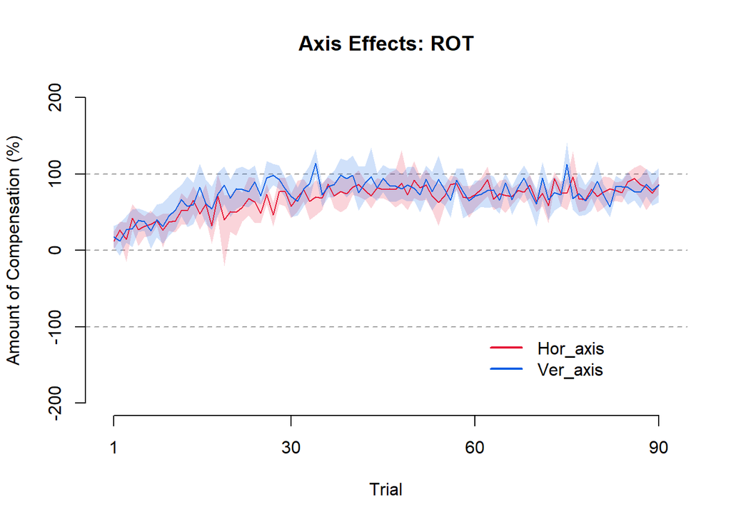

```r
plotNIROTAxisEffects()
```

```r
getLambdaAxisEffectsTTest(perturbation = 'ROT')
```

```
## Frequentist t-test (perturbation: ROT, condition: horizontal vs. vertical):
##
##  Welch Two Sample t-test
##
## data:  subdat1 and subdat2
## t = 0.075719, df = 9.3811, p-value = 0.9412
## alternative hypothesis: true difference in means is not equal to 0
## 95 percent confidence interval:
##  -0.1493674  0.1597794
## sample estimates:
## mean of x mean of y
## 0.1371307 0.1319247
##
## Bayesian t-test (perturbation: ROT, condition: horizontal vs. vertical):
## Bayes factor analysis
## --------------
## [1] Alt., r=0.707 : 0.4284234 ±0%
##
## Against denominator:
##   Null, mu1-mu2 = 0
## ---
## Bayes factor type: BFindepSample, JZS
```

```r
getAsymptoteAxisEffectsTTest(perturbation = 'ROT')
```

```
## Frequentist t-test (perturbation: ROT, condition: horizontal vs. vertical):
##
##  Welch Two Sample t-test
##
## data:  subdat1 and subdat2
## t = -0.32597, df = 13.332, p-value = 0.7495
## alternative hypothesis: true difference in means is not equal to 0
## 95 percent confidence interval:
##  -16.20265  11.94481
## sample estimates:
## mean of x mean of y
##  80.57179  82.70071
##
## Bayesian t-test (perturbation: ROT, condition: horizontal vs. vertical):
## Bayes factor analysis
## --------------
## [1] Alt., r=0.707 : 0.4433759 ±0%
##
## Against denominator:
##   Null, mu1-mu2 = 0
## ---
## Bayes factor type: BFindepSample, JZS
```

There are no axis effects, regardless of whether the perturbation is experienced on the horizontal or vertical axis of the workspace.

#### Mirror reversal

We also test for axis effects with the mirror reversed perturbation.

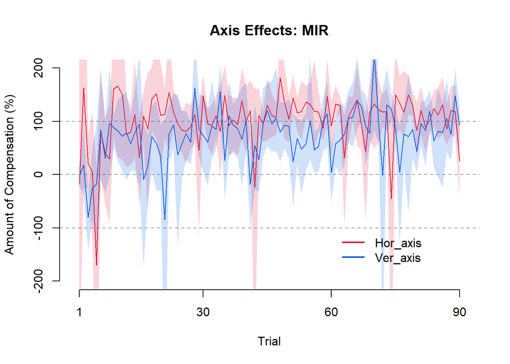

```r
plotNIMIRAxisEffects()
```

```r
getLambdaAxisEffectsTTest(perturbation = 'MIR')
```

```
## Frequentist t-test (perturbation: MIR, condition: horizontal vs. vertical):
##
##  Welch Two Sample t-test
##
## data:  subdat1 and subdat2
## t = 0.70209, df = 10.758, p-value = 0.4975
## alternative hypothesis: true difference in means is not equal to 0
## 95 percent confidence interval:
##  -0.1930714  0.3732157
## sample estimates:
## mean of x mean of y
## 0.2356096 0.1455375
##
## Bayesian t-test (perturbation: MIR, condition: horizontal vs. vertical):
## Bayes factor analysis
## --------------
## [1] Alt., r=0.707 : 0.5050626 ±0%
##
## Against denominator:
##   Null, mu1-mu2 = 0
## ---
## Bayes factor type: BFindepSample, JZS
```

```r
getAsymptoteAxisEffectsTTest(perturbation = 'MIR')
```

```
## Frequentist t-test (perturbation: MIR, condition: horizontal vs. vertical):
##
##  Welch Two Sample t-test
##
## data:  subdat1 and subdat2
## t = -1.1488, df = 7.6784, p-value = 0.2852
## alternative hypothesis: true difference in means is not equal to 0
## 95 percent confidence interval:
##  -209.11326   70.71935
## sample estimates:
## mean of x mean of y
##  115.7796  184.9765
##
## Bayesian t-test (perturbation: MIR, condition: horizontal vs. vertical):
## Bayes factor analysis
## --------------
## [1] Alt., r=0.707 : 0.6616324 ±0%
##
## Against denominator:
##   Null, mu1-mu2 = 0
## ---
## Bayes factor type: BFindepSample, JZS
```

We also do not find axis effects for the mirror reversal perturbation.

### Target location relative to axis

There were six targets for each axis. Three of the six targets were on either end of the axis, but could be on its negative (before axis) or positive (after axis) side.

#### Rotation

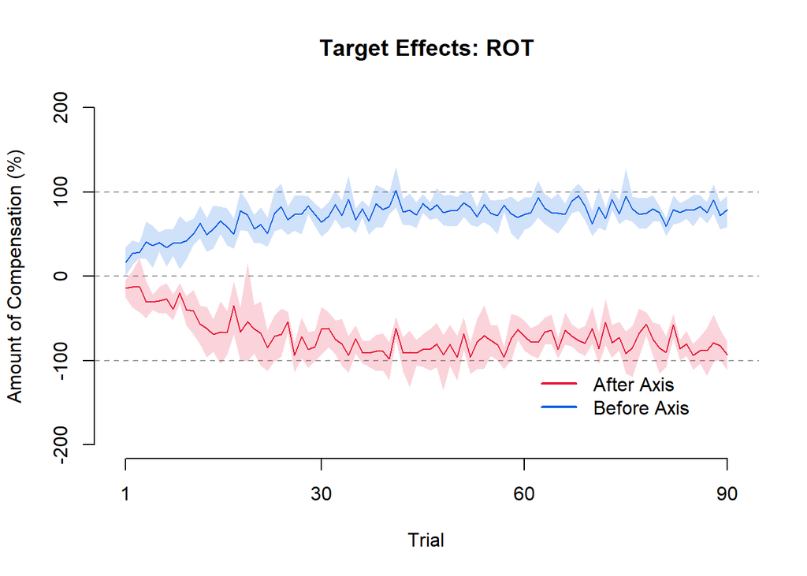

```r
plotNIROTTargetEffects()
```

For the statistical tests, we calculated a sign flip for targets that required a negative amount of compensation, such that we only compared the magnitude of the compensation. These values were then used to generate the exponential function fit parameters.

```r
getLambdaTargetEffectsTTest(perturbation = 'ROT')
```

```
## Frequentist t-test (perturbation: ROT, condition: after vs. before):
##
##  Welch Two Sample t-test
##
## data:  subdat1 and subdat2
## t = -1.1508, df = 7.9951, p-value = 0.2831
## alternative hypothesis: true difference in means is not equal to 0
## 95 percent confidence interval:
##  -0.22722622  0.07594933
## sample estimates:
## mean of x mean of y
## 0.0967085 0.1723469
##
## Bayesian t-test (perturbation: ROT, condition: after vs. before):
## Bayes factor analysis
## --------------
## [1] Alt., r=0.707 : 0.6625753 ±0%
##
## Against denominator:
##   Null, mu1-mu2 = 0
## ---
## Bayes factor type: BFindepSample, JZS
```

```r
getAsymptoteTargetEffectsTTest(perturbation = 'ROT')
```

```
## Frequentist t-test (perturbation: ROT, condition: after vs. before):
##
##  Welch Two Sample t-test
##
## data:  subdat1 and subdat2
## t = 0.38122, df = 13.933, p-value = 0.7088
## alternative hypothesis: true difference in means is not equal to 0
## 95 percent confidence interval:
##  -11.50821  16.48087
## sample estimates:
## mean of x mean of y
##  82.87942  80.39309
##
## Bayesian t-test (perturbation: ROT, condition: after vs. before):
## Bayes factor analysis
## --------------
## [1] Alt., r=0.707 : 0.4493055 ±0%
##
## Against denominator:
##   Null, mu1-mu2 = 0
## ---
## Bayes factor type: BFindepSample, JZS
```

We do not find any differences between learning rates and asymptotes, suggesting that there are no target location effects.

#### Mirror

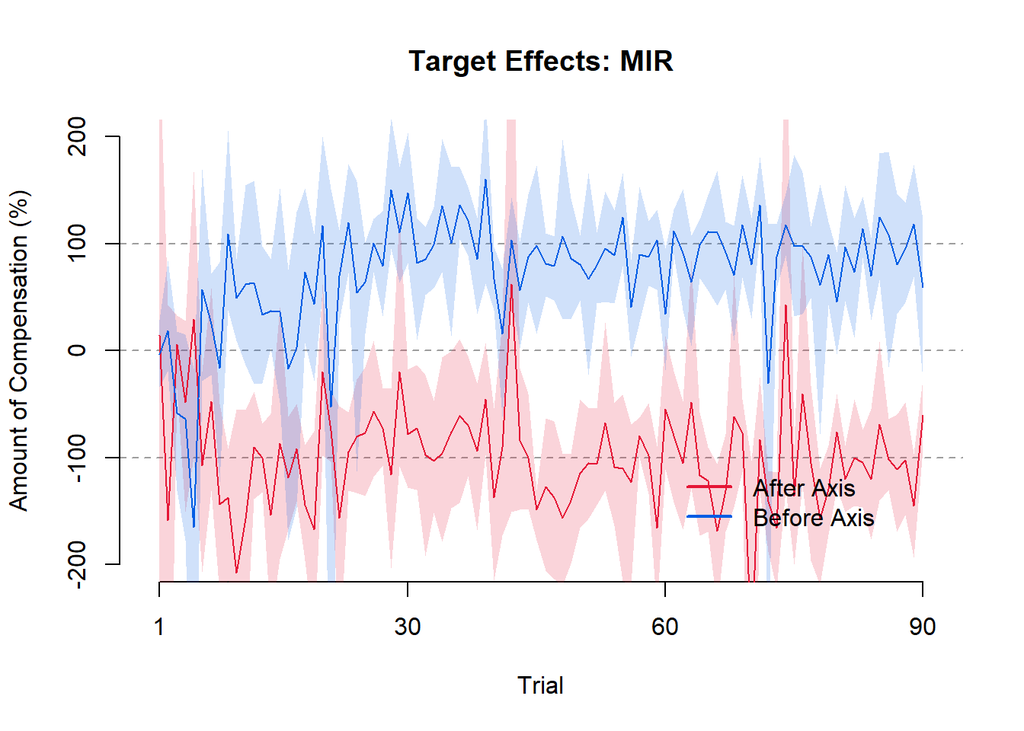

```r
plotNIMIRTargetEffects()
```

We again calculated a sign flip for targets that required a negative amount of compensation, then used these values to generate the exponential function fit parameters.

```r
getLambdaTargetEffectsTTest(perturbation = 'MIR')
```

```
## Frequentist t-test (perturbation: MIR, condition: after vs. before):
##
##  Welch Two Sample t-test
##
## data:  subdat1 and subdat2
## t = 1.9561, df = 7.2705, p-value = 0.0898
## alternative hypothesis: true difference in means is not equal to 0
## 95 percent confidence interval:
##  -0.04520438  0.49775895
## sample estimates:
##  mean of x  mean of y
## 0.30371221 0.07743493
##
## Bayesian t-test (perturbation: MIR, condition: after vs. before):
## Bayes factor analysis
## --------------
## [1] Alt., r=0.707 : 1.410721 ±0%
##
## Against denominator:
##   Null, mu1-mu2 = 0
## ---
## Bayes factor type: BFindepSample, JZS
```

```r
getAsymptoteTargetEffectsTTest(perturbation = 'MIR')
```

```
## Frequentist t-test (perturbation: MIR, condition: after vs. before):
##
##  Welch Two Sample t-test
##
## data:  subdat1 and subdat2
## t = 0.189, df = 13.988, p-value = 0.8528
## alternative hypothesis: true difference in means is not equal to 0
## 95 percent confidence interval:
##  -123.0843  146.8714
## sample estimates:
## mean of x mean of y
##  156.3249  144.4313
##
## Bayesian t-test (perturbation: MIR, condition: after vs. before):
## Bayes factor analysis
## --------------
## [1] Alt., r=0.707 : 0.432839 ±0%
##
## Against denominator:
##   Null, mu1-mu2 = 0
## ---
## Bayes factor type: BFindepSample, JZS
```

We do not find any differences between learning rates and asymptotes in frequentist tests, suggesting that there are no target locations effects. However, the Bayesian t-test comparing learning rates between target locations suggests anecdotal evidence for a target location effect. This is likely due to the variability in compensations during initial trials of learning.

## Learning Rates

As learning in the two perturbation types is independent of one another, we can then compare the progression of learning across trials between the rotation and mirror tasks. For the plots below, the y-axis will be the amount of compensation in percentage. This is because while the rotation magnitude is consistently 30-degrees, angular reach deviations for the mirror will differ depending on the target distance from the mirror axis. The mirror task will require reach deviations of 15, 30, or 45 degrees. Here, 100% would mean perfect compensation, 0% would be no compensation or reaching directly to the target, and negative values are compensations in the wrong direction relative to the target.

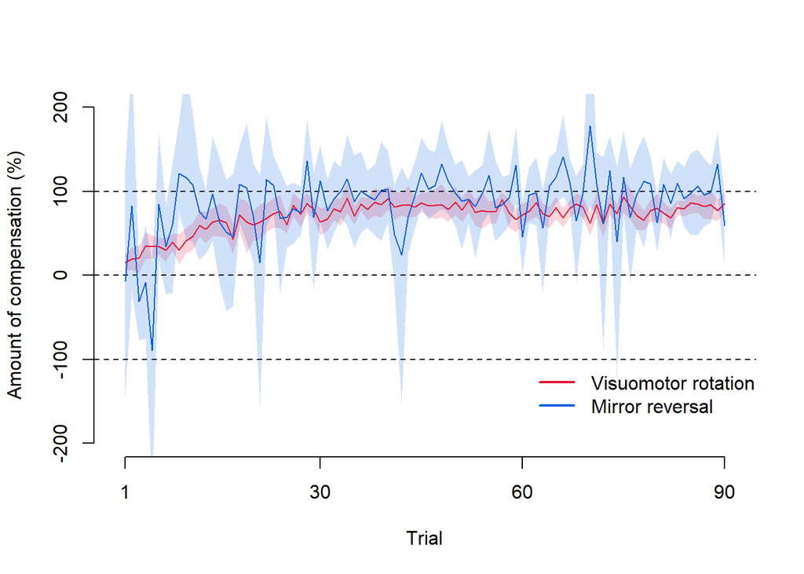

```r
plotPTypeLearningCurves(group='noninstructed')
```

We observe that although participants learned to compensate for both perturbation types, learning in the mirror reversed perturbation had a larger variability. We look into this further and show individual performance across blocks of six trials each.

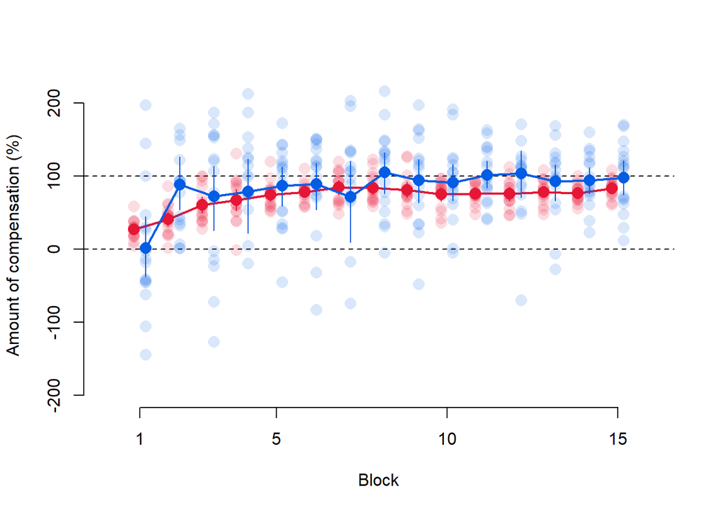

```r
plotCollapsedBlockedIndLC(group = 'noninstructed')
```

To compare learning between the two perturbation types, we fit the exponential decay function to data for each perturbation type. The function produced two measures, a rate of change and asymptote of learning. We then conducted a t-test to compare both measures between the two perturbation types.

```r
getLambdaLearningCurvesTTest()
```

```
## Frequentist t-test (Rotation vs. Mirror):
##
##  Welch Two Sample t-test
##
## data:  subdat1 and subdat2
## t = -0.78642, df = 22.731, p-value = 0.4397
## alternative hypothesis: true difference in means is not equal to 0
## 95 percent confidence interval:
##  -0.20356993  0.09147824
## sample estimates:
## mean of x mean of y
## 0.1345277 0.1905736
##
## Bayesian t-test (Rotation vs. Mirror):
## Bayes factor analysis
## --------------
## [1] Alt., r=0.707 : 0.426142 ±0%
##
## Against denominator:
##   Null, mu1-mu2 = 0
## ---
## Bayes factor type: BFindepSample, JZS
```

```r
getAsymptoteLearningCurvesTTest()
```

```
## Frequentist t-test (Rotation vs. Mirror):
##
##  Welch Two Sample t-test
##
## data:  subdat1 and subdat2
## t = -2.2465, df = 15.325, p-value = 0.03981
## alternative hypothesis: true difference in means is not equal to 0
## 95 percent confidence interval:
##  -133.844175   -3.639459
## sample estimates:
## mean of x mean of y
##  81.63625 150.37807
##
## Bayesian t-test (Rotation vs. Mirror):
## Bayes factor analysis
## --------------
## [1] Alt., r=0.707 : 2.145177 ±0.01%
##
## Against denominator:
##   Null, mu1-mu2 = 0
## ---
## Bayes factor type: BFindepSample, JZS
```

We do not find an effect for the rate of change in learning, suggesting no difference in the progression of learning between the two perturbation types. However, we do find an effect in the asymptote of learning, suggesting that learning asymptote for the mirror reversal was higher than in the rotation.

### Supplementary: Learning across three mirror target locations

Given the variability in learning for the mirror reversed perturbation, we investigated whether learning was dependent on the three different target locations.

First, we looked into the overall distribution of percentages of compensation per target location.

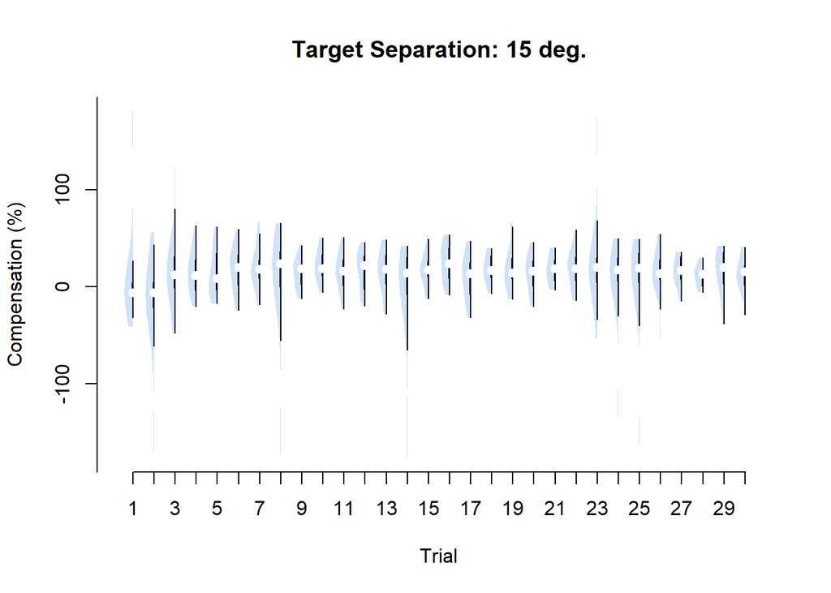

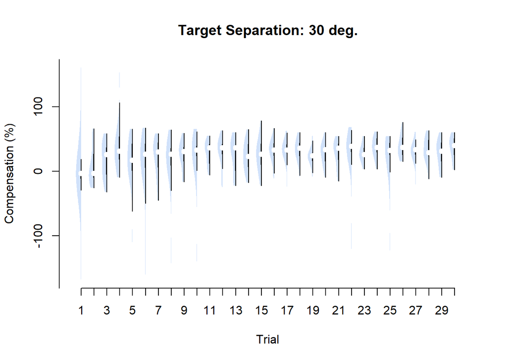

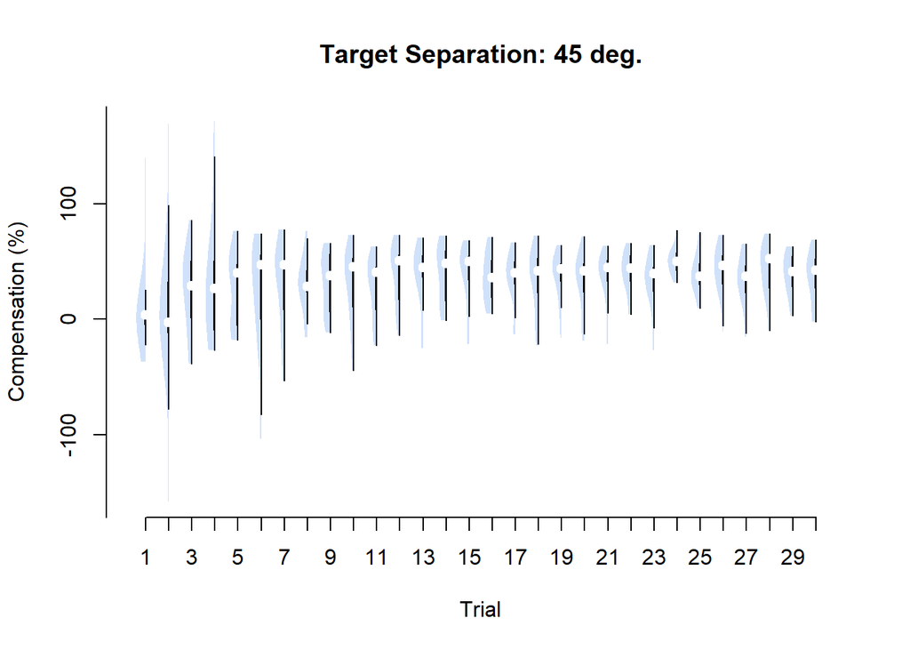

```r
getTargetCurveVioplots(group='noninstructed', maxppid=15, location='maxvel')
```

The distributions are overall as expected, i.e. there were no bimodal distributions. We then plot angular reach deviations per target location.

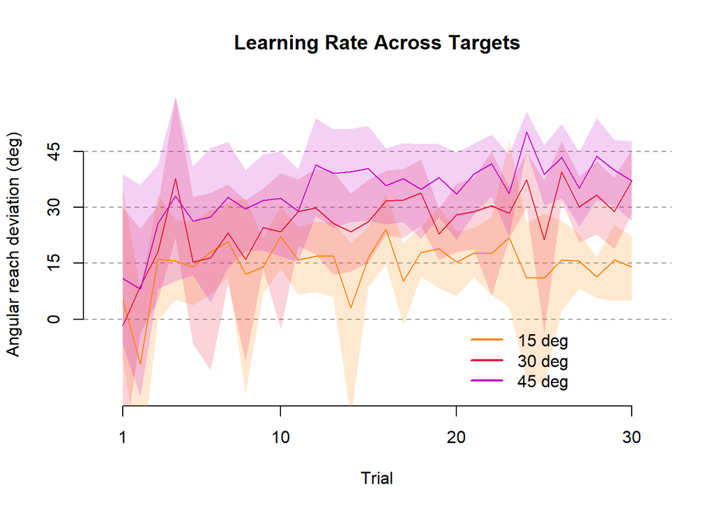

```r
plotNIMIRTargetCurve()
```

Although participants learned to compensate for all three target locations, it seems that variability for the target near the mirror axis (15 degrees) is larger. Therefore, we conducted the same analyses as in the previous section but removed all targets where participants had to deviate by 15 degrees.

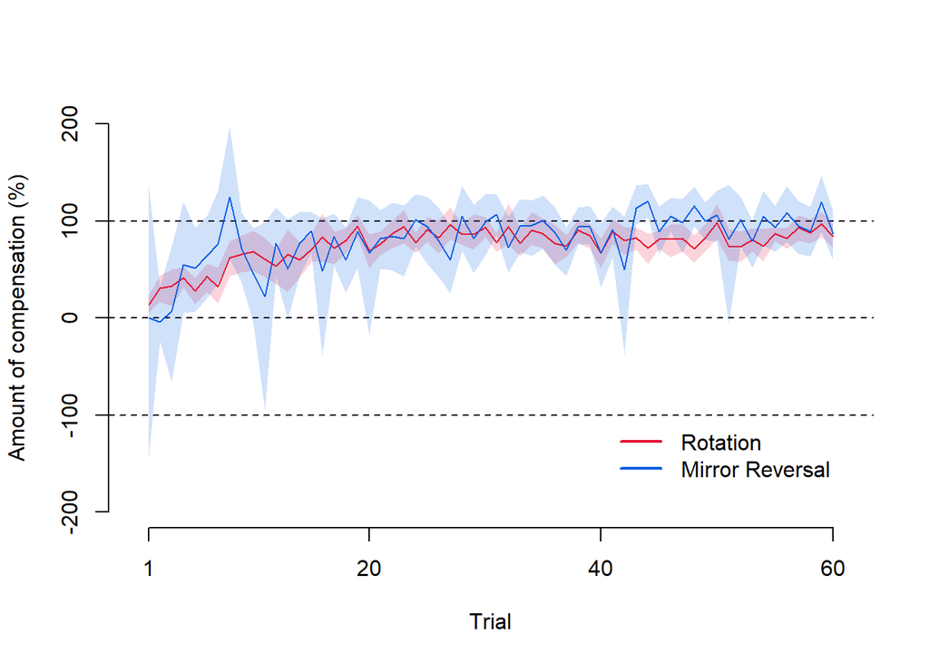

```r
plotPTypeLearningCurvesWONear()
```

Removing the 15 degree targets produced less variability, but learning in the mirror reversal still had a larger variability than the rotation.

```r
getLambdaLearningCurvesWONearTTest()
```

```
## Frequentist t-test (Rotation vs. Mirror):
##
##  Welch Two Sample t-test
##
## data:  subdat1 and subdat2
## t = -1.083, df = 22.465, p-value = 0.2903
## alternative hypothesis: true difference in means is not equal to 0
## 95 percent confidence interval:
##  -0.2656091  0.0832296
## sample estimates:
## mean of x mean of y
## 0.1901400 0.2813298
##
## Bayesian t-test (Rotation vs. Mirror):
## Bayes factor analysis
## --------------
## [1] Alt., r=0.707 : 0.5257425 ±0%
##
## Against denominator:
##   Null, mu1-mu2 = 0
## ---
## Bayes factor type: BFindepSample, JZS
```

```r
getAsymptoteLearningCurvesWONearTTest()
```

```
## Frequentist t-test (Rotation vs. Mirror):
##
##  Welch Two Sample t-test
##
## data:  subdat1 and subdat2
## t = -1.669, df = 15.243, p-value = 0.1155
## alternative hypothesis: true difference in means is not equal to 0
## 95 percent confidence interval:
##  -164.90019   19.95178
## sample estimates:
## mean of x mean of y
##  86.08078 158.55499
##
## Bayesian t-test (Rotation vs. Mirror):
## Bayes factor analysis
## --------------
## [1] Alt., r=0.707 : 0.9563318 ±0%
##
## Against denominator:
##   Null, mu1-mu2 = 0
## ---
## Bayes factor type: BFindepSample, JZS
```

We conducted the same t-tests to compare learning rates and asymptotes between the two perturbation types. We found that after removing the 15 degree target, there are no effects in rate and asymptote, suggesting that the 15 degree target contributed to higher asymptotes in learning the mirror reversed perturbation.

## Reach aftereffects

We then use washout trials following perturbation training to investigate whether reach aftereffects are observed. We expected to observe reach aftereffects following rotation training, but not mirror reversal training.

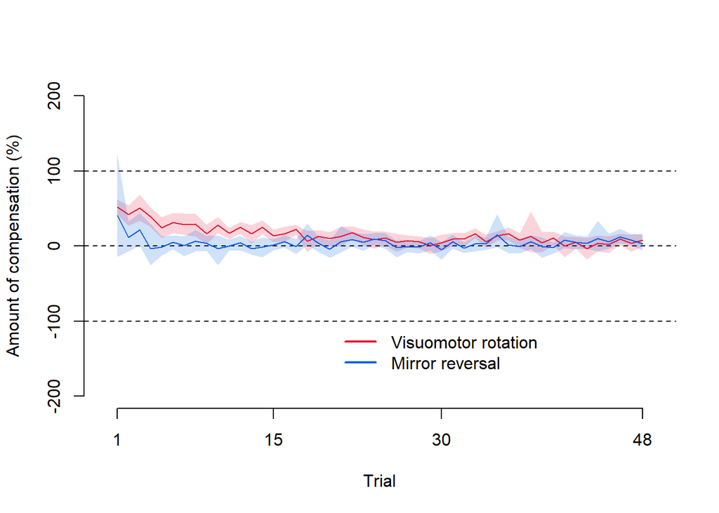

```r
plotPTypeAftereffects()
```

We can also show individual performance across blocks of six trials each.

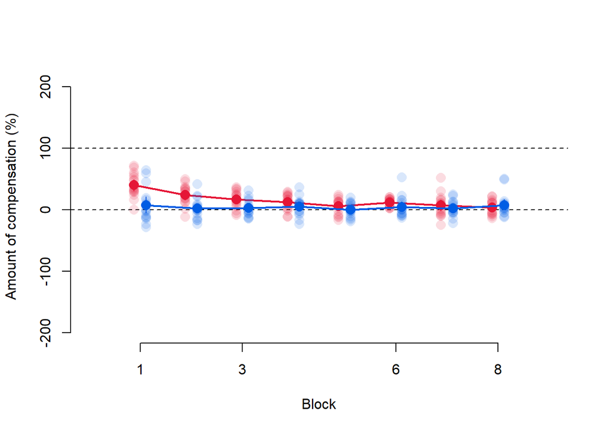

```r
plotCollapsedBlockedIndRAE()
```

We observe aftereffects following rotation training but not after mirror reversal training. This is supported by looking into the individual targets for the mirror reversal. Angular reach deviations show that the rate of de-adaptation is around zero across washout trials.

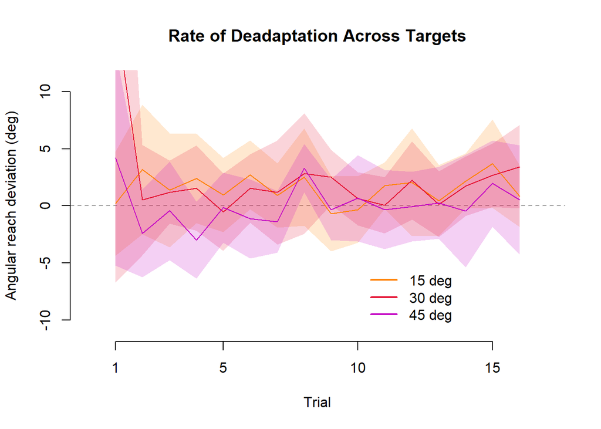

```r
plotNIRAETargetCurve()
```

It is possible to fit an exponential decay function to the washout data, where it starts at the asymptote and approaches zero over time. The exponential function can be fit into washout trials following rotation training. However, given that the washout trials after mirror reversal training are around zero, it would not make sense to fit the function to this data.

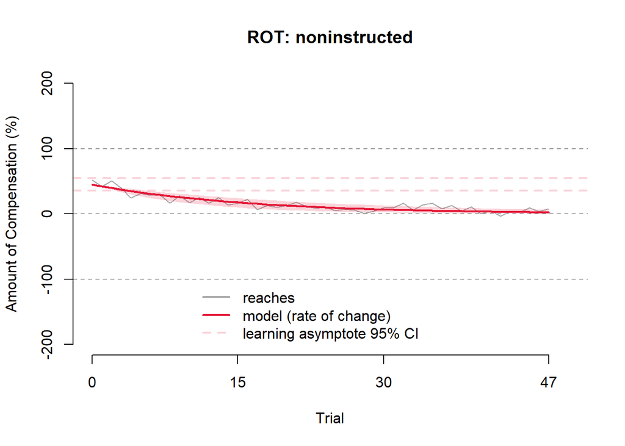

```r
plotROTRAEModel(groups='noninstructed')
```

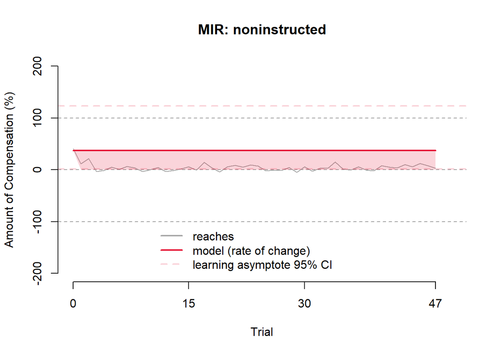

```r
plotMIRRAEModel(groups='noninstructed')
```

We therefore confirmed the presence of reach aftereffects by comparing the percentages of compensation during the last block of aligned reaches with the first block of each of the corresponding washout trials after rotated and mirror reversed training.

```r
RAEt.test(group='noninstructed')
```

```
## Aligned (last block) compared to Rotation Washout (first block):
##
##  Paired t-test
##
## data:  ALdat$compensation and ROTdat$compensation
## t = -8.5651, df = 15, p-value = 3.679e-07
## alternative hypothesis: true mean difference is not equal to 0
## 95 percent confidence interval:
##  -57.85656 -34.79894
## sample estimates:
## mean difference
##       -46.32775
##
## Effect Size - Cohen d:
## [1] 3.180562
## Bayesian t-test Aligned (last block) compared to Rotation Washout (first block):
## Bayes factor analysis
## --------------
## [1] Alt., r=0.707 : 12748734 ±0%
##
## Against denominator:
##   Null, mu1-mu2 = 0
## ---
## Bayes factor type: BFindepSample, JZS
##
## Aligned (last block) compared to Mirror Washout (first block):
##
##  Paired t-test
##
## data:  ALdat$compensation and MIRdat$compensation
## t = -2.0185, df = 15, p-value = 0.06178
## alternative hypothesis: true mean difference is not equal to 0
## 95 percent confidence interval:
##  -28.1993350   0.7673049
## sample estimates:
## mean difference
##       -13.71602
##
## Effect Size - Cohen d:
## [1] 0.6798059
```

[output cut: 19 more lines]

```
## sample estimates:
## mean difference
##        32.61174
##
## Effect Size - Cohen d:
## [1] 1.361953
## Bayesian t-test Rotation Washout (first block) compared to Mirror Washout (first block):
## Bayes factor analysis
## --------------
## [1] Alt., r=0.707 : 48.93883 ±0%
##
## Against denominator:
##   Null, mu1-mu2 = 0
## ---
## Bayes factor type: BFindepSample, JZS
```

We find an effect between aligned and rotated blocks, but not between aligned and mirror reversed blocks, confirming our expectations that aftereffects are only observed following rotation training. Moreover, we find an effect between the first washout blocks following rotation and mirror reversed training. We then compared the corresponding washout trials of rotation and mirror reversed training during the first, second, and last blocks of trials (trials 1-6, 7-12, 43-48).

```r
reachaftereffectsANOVA(group='noninstructed')
```

```
## $ANOVA
##              Effect DFn DFd        F            p p<.05       ges
## 2       perturbtype   1  15 10.03195 6.376323e-03     * 0.1782152
## 3             block   2  30 18.24462 6.539565e-06     * 0.1396883
## 4 perturbtype:block   2  30 16.11864 1.762222e-05     * 0.1481931
##
## $`Mauchly's Test for Sphericity`
##              Effect         W           p p<.05
## 3             block 0.6020397 0.028666577     *
## 4 perturbtype:block 0.4964129 0.007428502     *
##
## $`Sphericity Corrections`
##              Effect       GGe       p[GG] p[GG]<.05       HFe        p[HF]
## 3             block 0.7153279 9.00959e-05         * 0.7697679 5.444034e-05
## 4 perturbtype:block 0.6650762 2.82235e-04         * 0.7052909 2.018786e-04
##   p[HF]<.05
## 3         *
## 4         *
```

```r
reachaftereffectsBayesANOVA(group='noninstructed')
```

```
## Bayes factor analysis
## --------------
## [1] perturbtype + participant                             : 492.2176 ±0.78%
## [2] block + participant                                   : 16.18983 ±1.41%
## [3] perturbtype + block + participant                     : 26102.63 ±1.55%
## [4] perturbtype + block + perturbtype:block + participant : 7523736  ±1.14%
##
## Against denominator:
##   compensation ~ participant
## ---
## Bayes factor type: BFlinearModel, JZS
##
## Inclusion Bayes Factors (Model Averaged)
##
##                   P(prior) P(posterior) Inclusion BF
## participant           1.00         1.00
## perturbtype           0.60         1.00     2.93e+05
## block                 0.60         1.00     1.02e+04
## block:perturbtype     0.20         1.00     1.13e+03
##
## * Compared among: all models
## *    Priors odds: uniform-equal
```

We find a significant perturbation type by block interaction.

```r
RAEComparisonsAllBlocksEffSize(group='noninstructed')
```

```
##  contrast                    estimate   SE df t.ratio p.value
##  Block1: MIR vs. Block2: MIR    5.326 5.06 15   1.053  1.0000
##  Block1: MIR vs. Block3: MIR   -0.203 6.87 15  -0.030  1.0000
##  Block1: ROT vs. Block2: ROT   15.838 3.10 15   5.110  0.0009
##  Block1: ROT vs. Block3: ROT   36.074 4.06 15   8.877  <.0001
##  Block1: ROT vs. MIR          -32.612 8.28 15  -3.938  0.0092
##  Block2: ROT vs. MIR          -22.099 5.30 15  -4.170  0.0058
##  Block3: ROT vs. MIR            3.665 5.76 15   0.637  1.0000
##
## P value adjustment: bonferroni method for 7 tests
##                      contrast   etasquared
## 1 Block1: MIR vs. Block2: MIR 6.884968e-02
## 2 Block1: MIR vs. Block3: MIR 5.823273e-05
## 3 Block1: ROT vs. Block2: ROT 6.351304e-01
## 4 Block1: ROT vs. Block3: ROT 8.400960e-01
## 5         Block1: ROT vs. MIR 5.083788e-01
## 6         Block2: ROT vs. MIR 5.368444e-01
## 7         Block3: ROT vs. MIR 2.630462e-02
```

```r
reachaftereffectsBayesfollowup(group='noninstructed')
```

```
## Bayesian t-test Mirror block 1 vs block 2:
## Bayes factor analysis
## --------------
## [1] Alt., r=0.707 : 0.3972204 ±0%
##
## Against denominator:
##   Null, mu1-mu2 = 0
## ---
## Bayes factor type: BFindepSample, JZS
##
## Bayesian t-test Mirror block 1 vs last block:
## Bayes factor analysis
## --------------
## [1] Alt., r=0.707 : 0.3362827 ±0%
##
## Against denominator:
##   Null, mu1-mu2 = 0
## ---
## Bayes factor type: BFindepSample, JZS
##
## Bayesian t-test Rotation block 1 vs block 2:
## Bayes factor analysis
## --------------
## [1] Alt., r=0.707 : 3.335568 ±0.01%
##
## Against denominator:
##   Null, mu1-mu2 = 0
## ---
## Bayes factor type: BFindepSample, JZS
##
## Bayesian t-test Rotation block 1 vs last block:
## Bayes factor analysis
## --------------
## [1] Alt., r=0.707 : 22218.73 ±0%
##
## Against denominator:
##   Null, mu1-mu2 = 0
## ---
## Bayes factor type: BFindepSample, JZS
##
```

[output cut: 14 more lines]

```
##
## Against denominator:
##   Null, mu1-mu2 = 0
## ---
## Bayes factor type: BFindepSample, JZS
##
## Bayesian t-test Rotation  last block vs Mirror  last block:
## Bayes factor analysis
## --------------
## [1] Alt., r=0.707 : 0.4028267 ±0%
##
## Against denominator:
##   Null, mu1-mu2 = 0
## ---
## Bayes factor type: BFindepSample, JZS
```

Follow up tests confirm that the first and second rotation washout blocks are different from the first and second mirror washout blocks.

### Supplementary: Training rate of learning and its association with aftereffects

We also wanted to test whether learning rates during training correlate to the aftereffects, or lack thereof, during washout trials. To do this, we conducted correlation tests that compared the rate of change during learning with the compensation percentages during the first block of washout trials.

```r
getLambdaRAECorrelations(group='noninstructed')
```

```
##
##  Pearson's product-moment correlation
##
## data:  MIRfirst$lambda and MIRfirst$compensation
## t = -0.04915, df = 14, p-value = 0.9615
## alternative hypothesis: true correlation is not equal to 0
## 95 percent confidence interval:
##  -0.5055484  0.4857333
## sample estimates:
##         cor
## -0.01313462
##
##
##  Pearson's product-moment correlation
##
## data:  ROTfirst$lambda and ROTfirst$compensation
## t = -0.40671, df = 14, p-value = 0.6904
## alternative hypothesis: true correlation is not equal to 0
## 95 percent confidence interval:
##  -0.5730698  0.4095834
## sample estimates:
##       cor
## -0.108062
##
## Bayes factor analysis
## --------------
## [1] Alt., r=0.333 : 0.5194012 ±0%
##
## Against denominator:
##   Null, rho = 0
## ---
## Bayes factor type: BFcorrelation, Jeffreys-beta*
##
## Bayes factor analysis
## --------------
## [1] Alt., r=0.333 : 0.5510508 ±0%
##
## Against denominator:
##   Null, rho = 0
## ---
## Bayes factor type: BFcorrelation, Jeffreys-beta*
```

We do not find significant relationships between learning rates and corresponding aftereffects.

## Movement analyses

We compared other behavioral measures associated with reaching movements in both perturbation types.

### Reaction time

We defined reaction time (RT) as the time elapsed between the go signal onset and when the hand-cursor has moved 0.5 cm away from the start position.

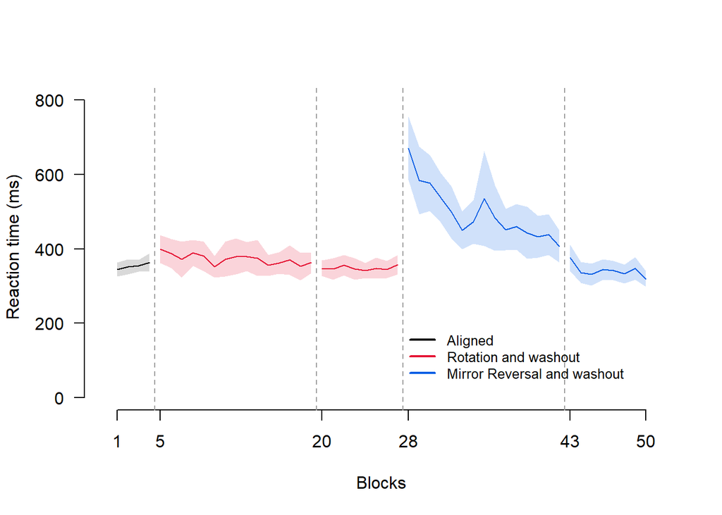

```r
plotNIBlockedRT()
```

To quantify changes in RT across rotation and mirror reversed training, we conducted t-tests to compare RTs in the last block of aligned reaches with the RTs in the first and last blocks of rotation or mirror reversed reaches. We also conducted t-tests to compare RTs in the last block of aligned reaches with the RTs in the first blocks of washout reaches following each perturbation training.

```r
RTt.test(group='noninstructed')
```

```
## Aligned (last block) compared to Rotation (first block):
##
##  Paired t-test
##
## data:  ALdat$compensation and ROTdat$compensation
## t = -3.1381, df = 15, p-value = 0.00677
## alternative hypothesis: true mean difference is not equal to 0
## 95 percent confidence interval:
##  -60.26283 -11.51174
## sample estimates:
## mean difference
##       -35.88729
##
## Effect Size - Cohen d:
## [1] 0.6072004
## Bayesian t-test Aligned (last block) compared to Rotation (first block):
## Bayes factor analysis
## --------------
## [1] Alt., r=0.707 : 1.01522 ±0%
##
## Against denominator:
##   Null, mu1-mu2 = 0
## ---
## Bayes factor type: BFindepSample, JZS
##
## Aligned (last block) compared to Mirror (first block):
##
##  Paired t-test
##
## data:  ALdat$compensation and MIRdat$compensation
## t = -7.6317, df = 15, p-value = 1.531e-06
## alternative hypothesis: true mean difference is not equal to 0
## 95 percent confidence interval:
##  -392.4082 -221.0708
## sample estimates:
## mean difference
##       -306.7395
##
## Effect Size - Cohen d:
## [1] 2.613546
```

[output cut: 94 more lines]

```
## sample estimates:
## mean difference
##       -42.69416
##
## Effect Size - Cohen d:
## [1] 0.6554177
## Bayesian t-test Aligned (last block) compared to Mirror (last block):
## Bayes factor analysis
## --------------
## [1] Alt., r=0.707 : 1.211139 ±0.01%
##
## Against denominator:
##   Null, mu1-mu2 = 0
## ---
## Bayes factor type: BFindepSample, JZS
```

As expected, participants were slower in initiating movements in the first block of perturbation training, regardless of the perturbation type. However, we do see in the plot that participants were slower to initiate movements in mirror reversed reaches compared to rotated reaches. RTs taper off and go back to baseline levels for rotated reaches, but is still significantly slower than baseline levels for mirror reversed reaches at the end of training. There are no effects between aligned and washout reaches.

We also compared RTs between rotation and mirror reversed reaches across training trials.

```r
reactiontimeANOVA(group='noninstructed')
```

```
## $ANOVA
##              Effect DFn DFd        F            p p<.05       ges
## 2       perturbtype   1  15 46.37509 5.892717e-06     * 0.3841103
## 3             block   2  30 22.38240 1.125541e-06     * 0.2526722
## 4 perturbtype:block   2  30 11.51226 1.948353e-04     * 0.1608922
##
## $`Mauchly's Test for Sphericity`
##              Effect         W         p p<.05
## 3             block 0.8561149 0.3370733
## 4 perturbtype:block 0.9233985 0.5724323
##
## $`Sphericity Corrections`
##              Effect       GGe        p[GG] p[GG]<.05       HFe        p[HF]
## 3             block 0.8742137 4.417721e-06         * 0.9800662 1.397428e-06
## 4 perturbtype:block 0.9288488 2.984089e-04         * 1.0547300 1.948353e-04
##   p[HF]<.05
## 3         *
## 4         *
```

```r
RTBayesANOVA(group='noninstructed')
```

```
## Bayes factor analysis
## --------------
## [1] perturbtype + participant                             : 3644758      ±2.49%
## [2] block + participant                                   : 159.519      ±0.79%
## [3] perturbtype + block + participant                     : 39561785209  ±3.3%
## [4] perturbtype + block + perturbtype:block + participant : 1.287961e+13 ±1.57%
##
## Against denominator:
##   compensation ~ participant
## ---
## Bayes factor type: BFlinearModel, JZS
##
## Inclusion Bayes Factors (Model Averaged)
##
##                   P(prior) P(posterior) Inclusion BF
## participant           1.00         1.00
## perturbtype           0.60         1.00     5.37e+10
## block                 0.60         1.00     2.36e+06
## block:perturbtype     0.20         1.00     1.30e+03
##
## * Compared among: all models
## *    Priors odds: uniform-equal
```

We find a significant perturbation type by block interaction.

```r
RTComparisonsAllBlocksEffSize(group='noninstructed')
```

```
##  contrast            estimate   SE df t.ratio p.value
##  Block1: ROT vs. MIR    270.9 38.7 15   7.000  <.0001
##  Block2: ROT vs. MIR    196.2 48.4 15   4.053  0.0031
##  Block3: ROT vs. MIR     43.9 19.0 15   2.311  0.1064
##
## P value adjustment: bonferroni method for 3 tests
##              contrast etasquared
## 1 Block1: ROT vs. MIR  0.7656395
## 2 Block2: ROT vs. MIR  0.5227581
## 3 Block3: ROT vs. MIR  0.2625601
```

```r
RTBayesfollowup(group='noninstructed')
```

```
## Bayesian t-test Rotation block 1 vs Mirror block 1:
## Bayes factor analysis
## --------------
## [1] Alt., r=0.707 : 14625.19 ±0%
##
## Against denominator:
##   Null, mu1-mu2 = 0
## ---
## Bayes factor type: BFindepSample, JZS
##
## Bayesian t-test Rotation block 2 vs Mirror block 2:
## Bayes factor analysis
## --------------
## [1] Alt., r=0.707 : 115.1938 ±0%
##
## Against denominator:
##   Null, mu1-mu2 = 0
## ---
## Bayes factor type: BFindepSample, JZS
##
## Bayesian t-test Rotation  last block vs Mirror  last block:
## Bayes factor analysis
## --------------
## [1] Alt., r=0.707 : 1.150233 ±0%
##
## Against denominator:
##   Null, mu1-mu2 = 0
## ---
## Bayes factor type: BFindepSample, JZS
```

Follow up tests show that rotation and mirror reversed RTs differed during the first and second blocks of training, and Bayesian tests showed anecdotal evidence of an effect between perturbation RTs in the last block of training. Overall, this shows that movement initiation is slower during mirror reversed perturbed reaches, compared to rotation perturbation reaches.

### Movement time

We defined movement time (MT) as the time elapsed between the first sample when the hand-cursor is >0.5 cm away from the start position and the first sample when the hand-cursor is greater than the start-to-target distance

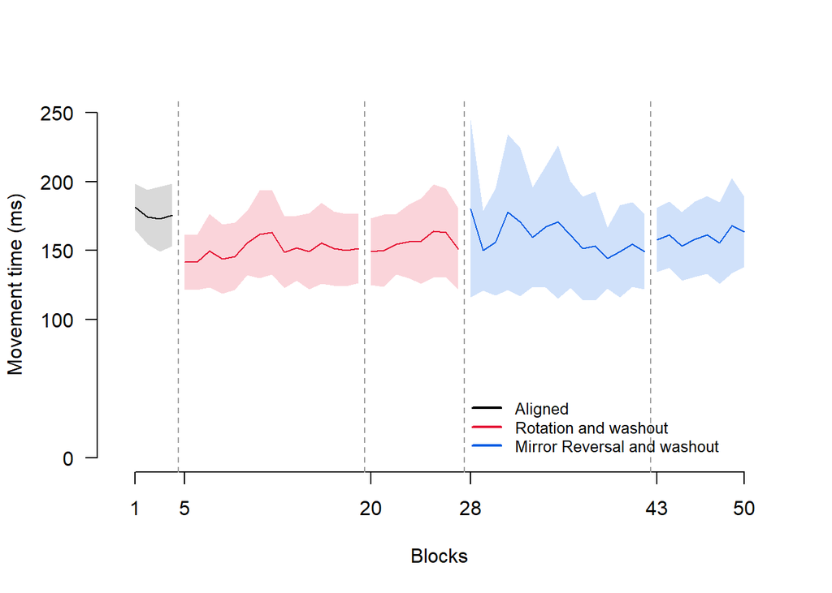

```r
plotNIBlockedMT()
```

To quantify changes in MT across rotation and mirror reversed training, we conducted the same t-tests as in the reaction time analysis. We compared MTs in the last block of aligned reaches with the MTs in the first and last blocks of rotation or mirror reversed reaches. We also conducted t-tests to compare MTs in the last block of aligned reaches with the MTs in the first blocks of washout reaches following each perturbation training.

```r
MTt.test(group='noninstructed')
```

```
## Aligned (last block) compared to Rotation (first block):
##
##  Paired t-test
##
## data:  ALdat$compensation and ROTdat$compensation
## t = 3.5038, df = 15, p-value = 0.003198
## alternative hypothesis: true mean difference is not equal to 0
## 95 percent confidence interval:
##  13.36498 54.87910
## sample estimates:
## mean difference
##        34.12204
##
## Effect Size - Cohen d:
## [1] 0.8538119
## Bayesian t-test Aligned (last block) compared to Rotation (first block):
## Bayes factor analysis
## --------------
## [1] Alt., r=0.707 : 2.817218 ±0.01%
##
## Against denominator:
##   Null, mu1-mu2 = 0
## ---
## Bayes factor type: BFindepSample, JZS
##
## Aligned (last block) compared to Mirror (first block):
##
##  Paired t-test
##
## data:  ALdat$compensation and MIRdat$compensation
## t = -0.18063, df = 15, p-value = 0.8591
## alternative hypothesis: true mean difference is not equal to 0
## 95 percent confidence interval:
##  -56.97808  48.07529
## sample estimates:
## mean difference
##       -4.451395
##
## Effect Size - Cohen d:
## [1] 0.04928006
```

[output cut: 94 more lines]

```
## sample estimates:
## mean difference
##        26.45996
##
## Effect Size - Cohen d:
## [1] 0.5614742
## Bayesian t-test Aligned (last block) compared to Mirror (last block):
## Bayes factor analysis
## --------------
## [1] Alt., r=0.707 : 0.8683503 ±0%
##
## Against denominator:
##   Null, mu1-mu2 = 0
## ---
## Bayes factor type: BFindepSample, JZS
```

Participants were faster in executing movements during rotated reaches, compared to aligned baseline reaches. Interestingly, faster MTs were also observed in the first block of washout trials following rotation training. In contrast, MTs do not differ between aligned reaches and the first block of mirror reversed reaches or its corresponding washout trials. However, we do find faster MTs during the last block of mirror reversed reaches, when compared to aligned reaches.

We also compared MTs between rotation and mirror reversed reaches across training trials.

```r
movementtimePerturbANOVA(group='noninstructed')
```

```
## $ANOVA
##              Effect DFn DFd          F         p p<.05          ges
## 2       perturbtype   1  14 0.86020670 0.3693952       7.423837e-03
## 3             block   2  28 0.01775302 0.9824147       8.965923e-05
## 4 perturbtype:block   2  28 1.50180740 0.2401263       9.475055e-03
##
## $`Mauchly's Test for Sphericity`
##              Effect         W         p p<.05
## 3             block 0.6538806 0.0632033
## 4 perturbtype:block 0.9900824 0.9372679
##
## $`Sphericity Corrections`
##              Effect       GGe     p[GG] p[GG]<.05       HFe     p[HF] p[HF]<.05
## 3             block 0.7428761 0.9569098           0.8105275 0.9660618
## 4 perturbtype:block 0.9901798 0.2403111           1.1525051 0.2401263
```

```r
MTBayesANOVA(group='noninstructed')
```

```
## Bayes factor analysis
## --------------
## [1] perturbtype + participant                             : 0.4911988  ±1.19%
## [2] block + participant                                   : 0.09914088 ±0.69%
## [3] perturbtype + block + participant                     : 0.04819926 ±1.44%
## [4] perturbtype + block + perturbtype:block + participant : 0.01908579 ±2.52%
##
## Against denominator:
##   compensation ~ participant
## ---
## Bayes factor type: BFlinearModel, JZS
##
## Inclusion Bayes Factors (Model Averaged)
##
##                   P(prior) P(posterior) Inclusion BF
## participant           1.00         1.00
## perturbtype           0.60         0.34        0.339
## block                 0.60         0.10        0.074
## block:perturbtype     0.20         0.01        0.047
##
## * Compared among: all models
## *    Priors odds: uniform-equal
```

### Path length

We defined path length (PL) as the total distance, given x and y coordinates of the reach trajectory, traveled between movement onset and offset. Movement onset and offset are the start and end movement times defined in the previous section. The shortest path length to the target is a straight line spanning the start-to-target distance. However, movements are not perfectly straight and may travel in different directions, depending on the perturbation.

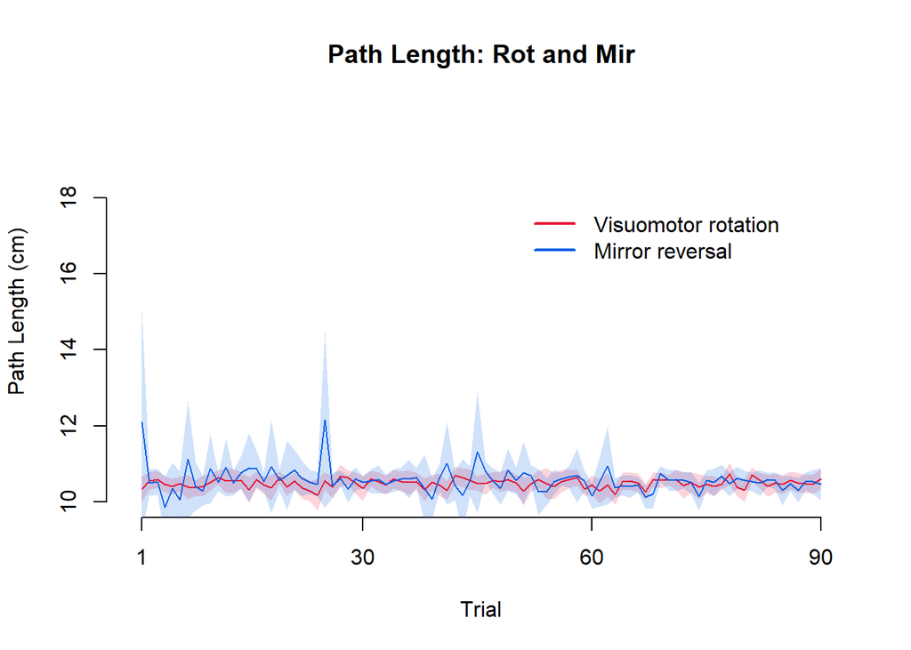

```r
plotPTypePathLength(group='noninstructed')
```

Similar to the other measures above, we conducted t-tests to compare PLs between the last block of aligned trials with the first and last blocks of rotation and mirror reversed training. We then compared PLs between the two perturbation types.

```r
PLt.test(group='noninstructed')
```

```
## Aligned (last block) compared to Rotation (first block):
##
##  Paired t-test
##
## data:  ALdat$compensation and ROTdat$compensation
## t = 1.8039, df = 15, p-value = 0.09136
## alternative hypothesis: true mean difference is not equal to 0
## 95 percent confidence interval:
##  -0.02151242  0.25849772
## sample estimates:
## mean difference
##       0.1184927
##
## Effect Size - Cohen d:
## [1] 0.5589686
## Bayesian t-test Aligned (last block) compared to Rotation (first block):
## Bayes factor analysis
## --------------
## [1] Alt., r=0.707 : 0.8612201 ±0%
##
## Against denominator:
##   Null, mu1-mu2 = 0
## ---
## Bayes factor type: BFindepSample, JZS
##
## Aligned (last block) compared to Mirror (first block):
##
##  Paired t-test
##
## data:  ALdat$compensation and MIRdat$compensation
## t = 0.45273, df = 15, p-value = 0.6572
## alternative hypothesis: true mean difference is not equal to 0
## 95 percent confidence interval:
##  -0.4456104  0.6859617
## sample estimates:
## mean difference
##       0.1201756
##
## Effect Size - Cohen d:
## [1] 0.1635101
```

[output cut: 44 more lines]

```
## sample estimates:
## mean difference
##       0.1585752
##
## Effect Size - Cohen d:
## [1] 0.5078908
## Bayesian t-test Aligned (last block) compared to Mirror (last block):
## Bayes factor analysis
## --------------
## [1] Alt., r=0.707 : 0.7333267 ±0%
##
## Against denominator:
##   Null, mu1-mu2 = 0
## ---
## Bayes factor type: BFindepSample, JZS
```

```r
pathlengthPerturbANOVA(group='noninstructed')
```

```
## $ANOVA
##              Effect DFn DFd         F         p p<.05         ges
## 2       perturbtype   1  15 0.1108586 0.7437769       0.001741464
## 3             block   2  30 0.7518656 0.4801633       0.009738404
## 4 perturbtype:block   2  30 0.7422843 0.4845656       0.013294868
##
## $`Mauchly's Test for Sphericity`
##              Effect         W           p p<.05
## 3             block 0.5018114 0.008012787     *
## 4 perturbtype:block 0.6308852 0.039778851     *
##
## $`Sphericity Corrections`
##              Effect       GGe     p[GG] p[GG]<.05       HFe     p[HF] p[HF]<.05
## 3             block 0.6674727 0.4333219           0.7083443 0.4402371
## 4 perturbtype:block 0.7303989 0.4474950           0.7892919 0.4566603
```

```r
PLBayesANOVA(group='noninstructed')
```

```
## Bayes factor analysis
## --------------
## [1] perturbtype + participant                             : 0.2435951   ±5.27%
## [2] block + participant                                   : 0.1499293   ±2.62%
## [3] perturbtype + block + participant                     : 0.03384444  ±1.96%
## [4] perturbtype + block + perturbtype:block + participant : 0.008989965 ±1.78%
##
## Against denominator:
##   compensation ~ participant
## ---
## Bayes factor type: BFlinearModel, JZS
##
## Inclusion Bayes Factors (Model Averaged)
##
##                   P(prior) P(posterior) Inclusion BF
## participant           1.00         1.00
## perturbtype           0.60         0.20        0.166
## block                 0.60         0.13        0.103
## block:perturbtype     0.20     6.26e-03        0.025
##
## * Compared among: all models
## *    Priors odds: uniform-equal
```

We do not find any effects across all comparisons, suggesting that the path of reach trajectories did not differ regardless of trial type or perturbation type.

## Instructed participants

For the instructed participants, we told them about the nature of each perturbation. We let them know that the rotation will be 30-degree rotation (CW or CCW depending on their ID), and that the mirror reversal will be dependent on which axis the mirror is placed. We also showed them animations of how to compensate for each perturbation type, and tested their understanding of the strategy by having them draw on a clock-face the location that they should move to bring a cursor to the target. For example, if the target is at 2 o’clock, then they had to draw an arrow to 1 o’clock to correct for a 30 degree CW rotation. In contrast, for a mirror placed along the vertical midline, a target at 2 o’clock would mean that they had to draw an arrow to the 10 position. We know from previous work that such instructions provide an advantage in early learning for rotation perturbations, and we wanted to test whether the same advantage will be observed for the mirror reversal.

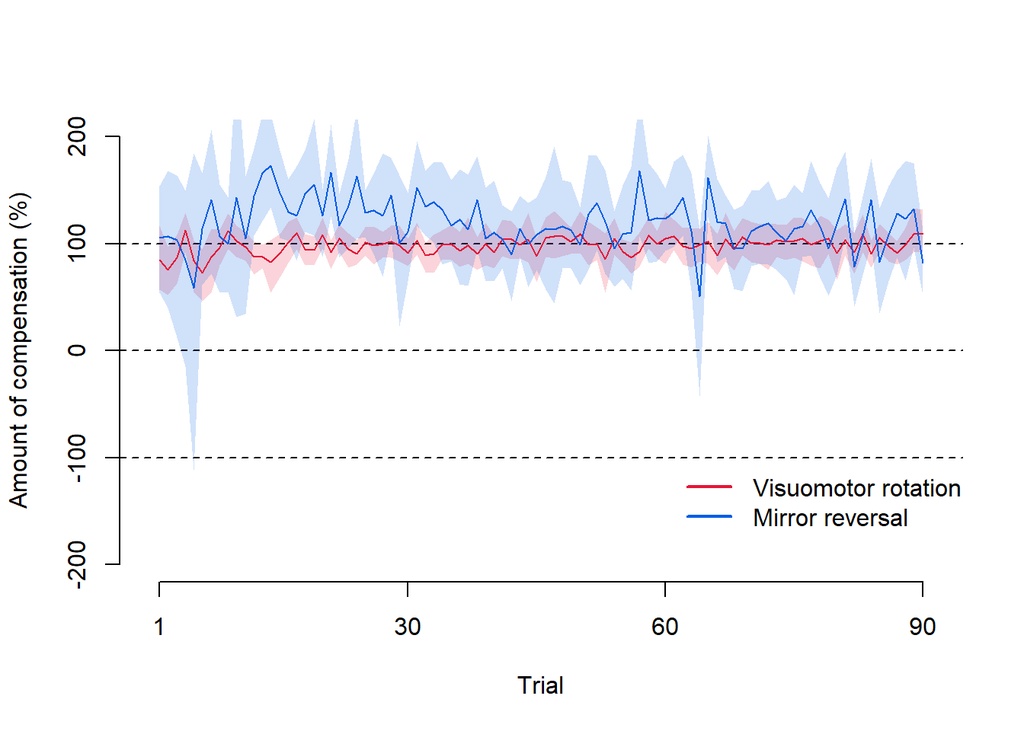

```r
plotPTypeLearningCurves(group='instructed')
```

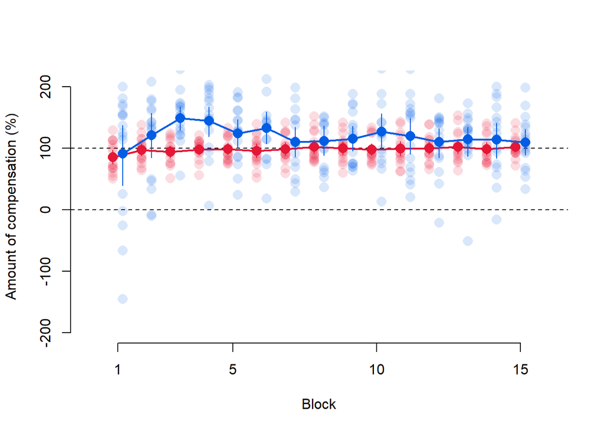

```r
plotCollapsedBlockedIndLC(group='instructed', maxppid=31)
```

We find that instructions did provide an advantage during the first few trials of training for both perturbation types, and that participants were immediately performing around perfect compensation. There was no change in learning across training, but we do find that mirror reversed reaches showed more variability.

### Reach aftereffects

We then investigated the corresponding washout trials for the instructed participants.

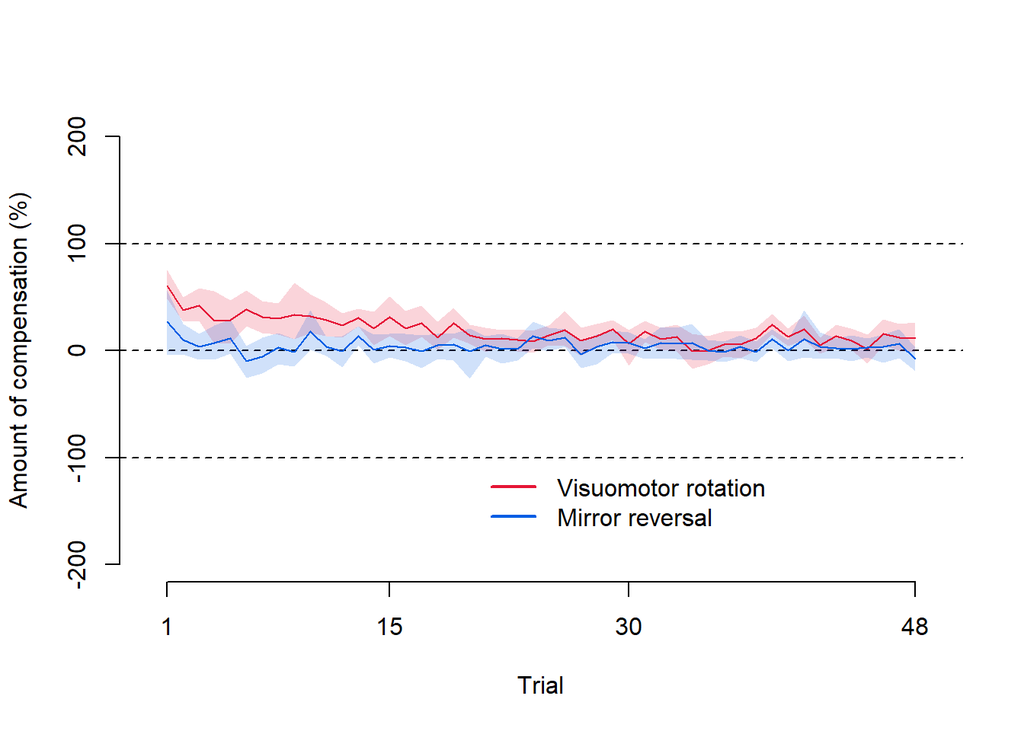

```r
plotPTypeAftereffects(group='instructed')
```

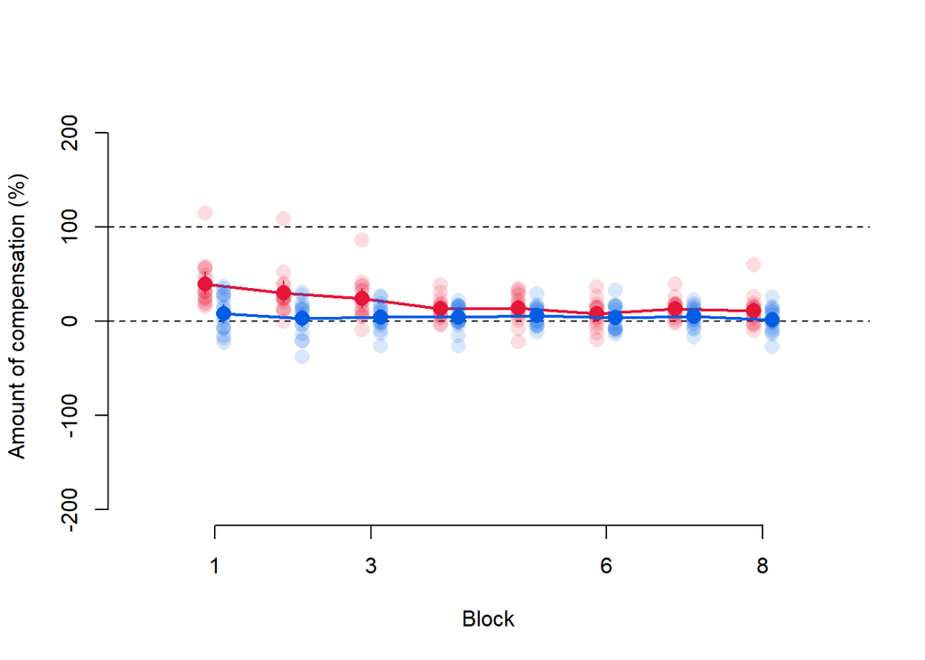

```r
plotCollapsedBlockedIndRAE(group='instructed', maxppid=31)
```

We repeated the reach aftereffects analyses we conducted for non-instructed participants with the instructed participants.

```r
RAEt.test(group='instructed')
```

```
## Aligned (last block) compared to Rotation Washout (first block):
##
##  Paired t-test
##
## data:  ALdat$compensation and ROTdat$compensation
## t = -6.9487, df = 15, p-value = 4.664e-06
## alternative hypothesis: true mean difference is not equal to 0
## 95 percent confidence interval:
##  -60.37988 -32.03296
## sample estimates:
## mean difference
##       -46.20642
##
## Effect Size - Cohen d:
## [1] 2.494295
## Bayesian t-test Aligned (last block) compared to Rotation Washout (first block):
## Bayes factor analysis
## --------------
## [1] Alt., r=0.707 : 123534.6 ±0%
##
## Against denominator:
##   Null, mu1-mu2 = 0
## ---
## Bayes factor type: BFindepSample, JZS
##
## Aligned (last block) compared to Mirror Washout (first block):
##
##  Paired t-test
##
## data:  ALdat$compensation and MIRdat$compensation
## t = -2.2901, df = 15, p-value = 0.03692
## alternative hypothesis: true mean difference is not equal to 0
## 95 percent confidence interval:
##  -29.074359  -1.043404
## sample estimates:
## mean difference
##       -15.05888
##
## Effect Size - Cohen d:
## [1] 0.973542
```

[output cut: 19 more lines]

```
## sample estimates:
## mean difference
##        31.14754
##
## Effect Size - Cohen d:
## [1] 1.394041
## Bayesian t-test Rotation Washout (first block) compared to Mirror Washout (first block):
## Bayes factor analysis
## --------------
## [1] Alt., r=0.707 : 60.07102 ±0%
##
## Against denominator:
##   Null, mu1-mu2 = 0
## ---
## Bayes factor type: BFindepSample, JZS
```

The first block of washout trials following rotation training differed from the last block of aligned baseline reaches, suggesting the presence of aftereffects. Interestingly, we also find an effect when comparing the first block of washout trials following mirror reversed reaches with aligned reaches. However, aftereffects were larger for washout trials following rotation training, than those following mirror reversed training. The presence of very small aftereffects in the mirror reversal washout trials is unexpected, but could be due to being able to know how to compensate for the perturbation from the beginning of training. That is, they were exposed to training with the mirror reversal longer than the non-instructed participants.

We compare rotation and mirror reversed washout trials further.

```r
reachaftereffectsANOVA(group='instructed')
```

```
## $ANOVA
##              Effect DFn DFd         F            p p<.05        ges
## 2       perturbtype   1  15 17.552155 7.894270e-04     * 0.25469337
## 3             block   2  30 15.471313 2.415469e-05     * 0.12293176
## 4 perturbtype:block   2  30  3.523014 4.223711e-02     * 0.05530366
##
## $`Mauchly's Test for Sphericity`
##              Effect         W          p p<.05
## 3             block 0.9355022 0.62706686
## 4 perturbtype:block 0.6096292 0.03129395     *
##
## $`Sphericity Corrections`
##              Effect       GGe        p[GG] p[GG]<.05      HFe        p[HF]
## 3             block 0.9394102 3.908057e-05         * 1.069306 2.415469e-05
## 4 perturbtype:block 0.7192326 6.065359e-02           0.774818 5.646370e-02
##   p[HF]<.05
## 3         *
## 4
```

```r
reachaftereffectsBayesANOVA(group='instructed')
```

```
## Bayes factor analysis
## --------------
## [1] perturbtype + participant                             : 74548.81 ±1.08%
## [2] block + participant                                   : 6.613389 ±0.51%
## [3] perturbtype + block + participant                     : 2548033  ±1.13%
## [4] perturbtype + block + perturbtype:block + participant : 4461813  ±3.93%
##
## Against denominator:
##   compensation ~ participant
## ---
## Bayes factor type: BFlinearModel, JZS
##
## Inclusion Bayes Factors (Model Averaged)
##
##                   P(prior) P(posterior) Inclusion BF
## participant           1.00         1.00
## perturbtype           0.60         1.00     6.20e+05
## block                 0.60         0.99        62.69
## block:perturbtype     0.20         0.63         6.81
##
## * Compared among: all models
## *    Priors odds: uniform-equal
```

We find a significant perturbation type by block interaction.

```r
RAEComparisonsAllBlocksEffSize(group='instructed')
```

```
##  contrast                    estimate   SE df t.ratio p.value
##  Block1: MIR vs. Block2: MIR     5.45 4.73 15   1.153  1.0000
##  Block1: MIR vs. Block3: MIR     6.88 5.05 15   1.364  1.0000
##  Block1: ROT vs. Block2: ROT     9.50 2.87 15   3.306  0.0336
##  Block1: ROT vs. Block3: ROT    28.45 7.27 15   3.911  0.0097
##  Block1: ROT vs. MIR           -31.15 8.24 15  -3.782  0.0127
##  Block2: ROT vs. MIR           -27.09 7.59 15  -3.568  0.0196
##  Block3: ROT vs. MIR            -9.58 6.04 15  -1.588  0.9323
##
## P value adjustment: bonferroni method for 7 tests
##                      contrast etasquared
## 1 Block1: MIR vs. Block2: MIR 0.08137381
## 2 Block1: MIR vs. Block3: MIR 0.11036641
## 3 Block1: ROT vs. Block2: ROT 0.42149321
## 4 Block1: ROT vs. Block3: ROT 0.50491506
## 5         Block1: ROT vs. MIR 0.48810223
## 6         Block2: ROT vs. MIR 0.45907447
## 7         Block3: ROT vs. MIR 0.14388642
```

```r
reachaftereffectsBayesfollowup(group='instructed')
```

```
## Bayesian t-test Mirror block 1 vs block 2:
## Bayes factor analysis
## --------------
## [1] Alt., r=0.707 : 0.4289297 ±0%
##
## Against denominator:
##   Null, mu1-mu2 = 0
## ---
## Bayes factor type: BFindepSample, JZS
##
## Bayesian t-test Mirror block 1 vs last block:
## Bayes factor analysis
## --------------
## [1] Alt., r=0.707 : 0.5561826 ±0%
##
## Against denominator:
##   Null, mu1-mu2 = 0
## ---
## Bayes factor type: BFindepSample, JZS
##
## Bayesian t-test Rotation block 1 vs block 2:
## Bayes factor analysis
## --------------
## [1] Alt., r=0.707 : 0.5317184 ±0%
##
## Against denominator:
##   Null, mu1-mu2 = 0
## ---
## Bayes factor type: BFindepSample, JZS
##
## Bayesian t-test Rotation block 1 vs last block:
## Bayes factor analysis
## --------------
## [1] Alt., r=0.707 : 49.6715 ±0%
##
## Against denominator:
##   Null, mu1-mu2 = 0
## ---
## Bayes factor type: BFindepSample, JZS
##
```

[output cut: 14 more lines]

```
##
## Against denominator:
##   Null, mu1-mu2 = 0
## ---
## Bayes factor type: BFindepSample, JZS
##
## Bayesian t-test Rotation  last block vs Mirror  last block:
## Bayes factor analysis
## --------------
## [1] Alt., r=0.707 : 1.156555 ±0.01%
##
## Against denominator:
##   Null, mu1-mu2 = 0
## ---
## Bayes factor type: BFindepSample, JZS
```

Follow up tests show that washout trials following rotation training show aftereffects that go back down near zero. Washout trials following mirror reversed trials, however, did not differ across blocks of trials. Thus, the small aftereffects for mirror reversed trials in the previous set of tests did not hold up here. Finally compensation in rotation washout trials were larger in the first and second blocks, compared to mirror reversed washout trials. Overall, it is clear that aftereffects are observed following rotation training only.

### Movement analyses

We also compared other behavioral measures associated with reaching movements in both perturbation types for the instructed participants.

#### Reaction time

We defined reaction time (RT) as the time elapsed between the go signal onset and when the hand-cursor has moved 0.5 cm away from the start position.

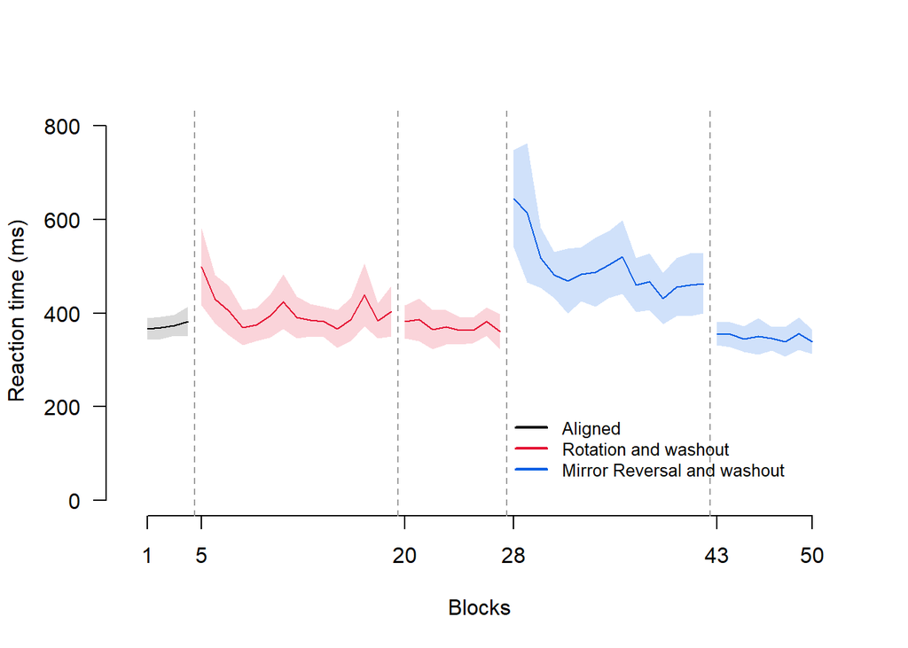

```r
plotIBlockedRT()
```

To quantify changes in RT across rotation and mirror reversed training, we conducted t-tests to compare RTs in the last block of aligned reaches with the RTs in the first and last blocks of rotation or mirror reversed reaches. We also conducted t-tests to compare RTs in the last block of aligned reaches with the RTs in the first blocks of washout reaches following each perturbation training.

```r
RTt.test(group='instructed')
```

```
## Aligned (last block) compared to Rotation (first block):
##
##  Paired t-test
##
## data:  ALdat$compensation and ROTdat$compensation
## t = -3.3466, df = 15, p-value = 0.004416
## alternative hypothesis: true mean difference is not equal to 0
## 95 percent confidence interval:
##  -192.04541  -42.59921
## sample estimates:
## mean difference
##       -117.3223
##
## Effect Size - Cohen d:
## [1] 1.00782
## Bayesian t-test Aligned (last block) compared to Rotation (first block):
## Bayes factor analysis
## --------------
## [1] Alt., r=0.707 : 6.102814 ±0%
##
## Against denominator:
##   Null, mu1-mu2 = 0
## ---
## Bayes factor type: BFindepSample, JZS
##
## Aligned (last block) compared to Mirror (first block):
##
##  Paired t-test
##
## data:  ALdat$compensation and MIRdat$compensation
## t = -5.8431, df = 15, p-value = 3.235e-05
## alternative hypothesis: true mean difference is not equal to 0
## 95 percent confidence interval:
##  -358.8209 -167.0079
## sample estimates:
## mean difference
##       -262.9144
##
## Effect Size - Cohen d:
## [1] 1.830453
```

[output cut: 94 more lines]

```
## sample estimates:
## mean difference
##       -81.51345
##
## Effect Size - Cohen d:
## [1] 0.8535032
## Bayesian t-test Aligned (last block) compared to Mirror (last block):
## Bayes factor analysis
## --------------
## [1] Alt., r=0.707 : 2.81313 ±0.01%
##
## Against denominator:
##   Null, mu1-mu2 = 0
## ---
## Bayes factor type: BFindepSample, JZS
```

The results are similar to those with the noninstructed participants. Participants were slower in initiating movements in the first block of perturbation training, regardless of the perturbation type. However, we do see in the plot that participants were slower to initiate movements in mirror reversed reaches compared to rotated reaches. RTs taper off and go back to baseline levels for rotated reaches, but is still significantly slower than baseline levels for mirror reversed reaches at the end of training. There are no effects between aligned and washout reaches.

We also compared RTs between rotation and mirror reversed reaches across training trials.

```r
reactiontimeANOVA(group='instructed')
```

```
## $ANOVA
##              Effect DFn DFd         F           p p<.05       ges
## 2       perturbtype   1  15 22.242789 0.000275758     * 0.1336356
## 3             block   2  30  7.985512 0.001657892     * 0.1071339
## 4 perturbtype:block   2  30  1.619007 0.214927836       0.0245030
##
## $`Mauchly's Test for Sphericity`
##              Effect         W          p p<.05
## 3             block 0.6264875 0.03787797     *
## 4 perturbtype:block 0.8348009 0.28254017
##
## $`Sphericity Corrections`
##              Effect       GGe       p[GG] p[GG]<.05       HFe       p[HF]
## 3             block 0.7280603 0.005002071         * 0.7862567 0.003944299
## 4 perturbtype:block 0.8582224 0.218883460           0.9584451 0.216156091
##   p[HF]<.05
## 3         *
## 4
```

```r
RTBayesANOVA(group='instructed')
```

```
## Bayes factor analysis
## --------------
## [1] perturbtype + participant                             : 309.6335 ±1.63%
## [2] block + participant                                   : 14.35494 ±0.54%
## [3] perturbtype + block + participant                     : 13514.44 ±1.23%
## [4] perturbtype + block + perturbtype:block + participant : 6852.301 ±1.57%
##
## Against denominator:
##   compensation ~ participant
## ---
## Bayes factor type: BFlinearModel, JZS
##
## Inclusion Bayes Factors (Model Averaged)
##
##                   P(prior) P(posterior) Inclusion BF
## participant           1.00         1.00
## perturbtype           0.60         1.00       897.71
## block                 0.60         0.98        43.74
## block:perturbtype     0.20         0.33         1.98
##
## * Compared among: all models
## *    Priors odds: uniform-equal
```

We find main effects for perturbation type and block.

```r
RTComparisonsAllBlocksEffSize(group='instructed')
```

```
##  contrast            estimate   SE df t.ratio p.value
##  Block1: ROT vs. MIR    145.6 47.8 15   3.045  0.0246
##  Block2: ROT vs. MIR    183.7 68.1 15   2.697  0.0496
##  Block3: ROT vs. MIR     58.9 19.6 15   2.999  0.0270
##
## P value adjustment: bonferroni method for 3 tests
##              contrast etasquared
## 1 Block1: ROT vs. MIR  0.3819464
## 2 Block2: ROT vs. MIR  0.3266135
## 3 Block3: ROT vs. MIR  0.3748060
```

```r
RTBayesfollowup(group='instructed')
```

```
## Bayesian t-test Rotation block 1 vs Mirror block 1:
## Bayes factor analysis
## --------------
## [1] Alt., r=0.707 : 2.546268 ±0.01%
##
## Against denominator:
##   Null, mu1-mu2 = 0
## ---
## Bayes factor type: BFindepSample, JZS
##
## Bayesian t-test Rotation block 2 vs Mirror block 2:
## Bayes factor analysis
## --------------
## [1] Alt., r=0.707 : 3.176157 ±0.01%
##
## Against denominator:
##   Null, mu1-mu2 = 0
## ---
## Bayes factor type: BFindepSample, JZS
##
## Bayesian t-test Rotation  last block vs Mirror  last block:
## Bayes factor analysis
## --------------
## [1] Alt., r=0.707 : 0.7744694 ±0%
##
## Against denominator:
##   Null, mu1-mu2 = 0
## ---
## Bayes factor type: BFindepSample, JZS
```

Follow up tests show that rotation and mirror reversed RTs differed across block of training. Overall, this confirms that movement initiation is slower during mirror reversed perturbed reaches, compared to rotation perturbation reaches.

#### Movement time

We defined movement time (MT) as the time elapsed between the first sample when the hand-cursor is >0.5 cm away from the start position and the first sample when the hand-cursor is greater than the start-to-target distance

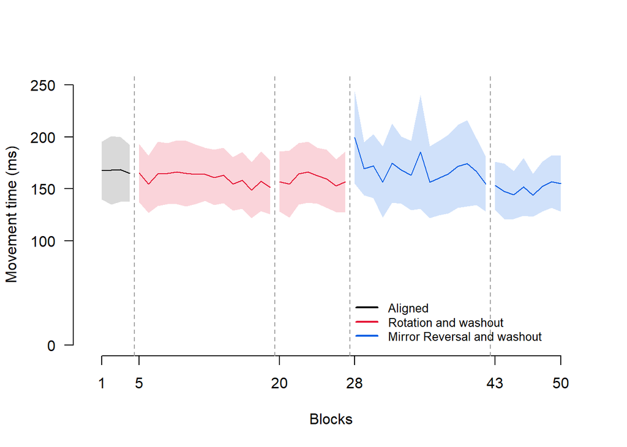

```r
plotIBlockedMT()
```

To quantify changes in MT across rotation and mirror reversed training, we conducted the same t-tests as in the reaction time analysis. We compared MTs in the last block of aligned reaches with the MTs in the first and last blocks of rotation or mirror reversed reaches. We also conducted t-tests to compare MTs in the last block of aligned reaches with the MTs in the first blocks of washout reaches following each perturbation training.

```r
MTt.test(group='instructed')
```

```
## Aligned (last block) compared to Rotation (first block):
##
##  Paired t-test
##
## data:  ALdat$compensation and ROTdat$compensation
## t = -0.026051, df = 15, p-value = 0.9796
## alternative hypothesis: true mean difference is not equal to 0
## 95 percent confidence interval:
##  -23.84831  23.27238
## sample estimates:
## mean difference
##       -0.287964
##
## Effect Size - Cohen d:
## [1] 0.005575588
## Bayesian t-test Aligned (last block) compared to Rotation (first block):
## Bayes factor analysis
## --------------
## [1] Alt., r=0.707 : 0.3362362 ±0%
##
## Against denominator:
##   Null, mu1-mu2 = 0
## ---
## Bayes factor type: BFindepSample, JZS
##
## Aligned (last block) compared to Mirror (first block):
##
##  Paired t-test
##
## data:  ALdat$compensation and MIRdat$compensation
## t = -1.7657, df = 15, p-value = 0.09779
## alternative hypothesis: true mean difference is not equal to 0
## 95 percent confidence interval:
##  -75.671969   7.102291
## sample estimates:
## mean difference
##       -34.28484
##
## Effect Size - Cohen d:
## [1] 0.4986822
```

[output cut: 94 more lines]

```
## sample estimates:
## mean difference
##        10.42391
##
## Effect Size - Cohen d:
## [1] 0.2072793
## Bayesian t-test Aligned (last block) compared to Mirror (last block):
## Bayes factor analysis
## --------------
## [1] Alt., r=0.707 : 0.3836858 ±0%
##
## Against denominator:
##   Null, mu1-mu2 = 0
## ---
## Bayes factor type: BFindepSample, JZS
```

COontrary to our findings with noninstructed participants, we found no effects for movement times across the different trial types for instructed participants.

We also compared MTs between rotation and mirror reversed reaches across training trials.

```r
movementtimePerturbANOVA(group='instructed')
```

```
## $ANOVA
##              Effect DFn DFd        F           p p<.05         ges
## 2       perturbtype   1  14 2.903503 0.110470854       0.011733371
## 3             block   2  28 8.888595 0.001025946     * 0.036601364
## 4 perturbtype:block   2  28 2.440166 0.105464379       0.007507154
##
## $`Mauchly's Test for Sphericity`
##              Effect         W           p p<.05
## 3             block 0.4914825 0.009881032     *
## 4 perturbtype:block 0.7713684 0.185012880
##
## $`Sphericity Corrections`
##              Effect       GGe       p[GG] p[GG]<.05       HFe       p[HF]
## 3             block 0.6629025 0.004702904         * 0.7056493 0.003871487
## 4 perturbtype:block 0.8139136 0.118010748           0.9059609 0.111665143
##   p[HF]<.05
## 3         *
## 4
```

```r
MTBayesANOVA(group='instructed')
```

```
## Bayes factor analysis
## --------------
## [1] perturbtype + participant                             : 1.356178 ±1.07%
## [2] block + participant                                   : 32.79583 ±1.67%
## [3] perturbtype + block + participant                     : 63.12171 ±1.8%
## [4] perturbtype + block + perturbtype:block + participant : 31.35467 ±1.34%
##
## Against denominator:
##   compensation ~ participant
## ---
## Bayes factor type: BFlinearModel, JZS
##
## Inclusion Bayes Factors (Model Averaged)
##
##                   P(prior) P(posterior) Inclusion BF
## participant           1.00         1.00
## perturbtype           0.60         0.74         1.89
## block                 0.60         0.98        36.01
## block:perturbtype     0.20         0.24         1.28
##
## * Compared among: all models
## *    Priors odds: uniform-equal
```

We find a main effect of block.

```r
MTPerturbComparisonsAllBlocksEffSize(group='instructed')
```

```
##  contrast                    estimate    SE df t.ratio p.value
##  Block1: MIR vs. Block2: MIR    16.70 10.84 14   1.541  1.0000
##  Block1: MIR vs. Block3: MIR    35.17 12.21 14   2.879  0.0849
##  Block1: ROT vs. Block2: ROT    11.29  3.46 14   3.263  0.0397
##  Block1: ROT vs. Block3: ROT    13.99  4.73 14   2.960  0.0723
##  Block1: ROT vs. MIR            20.12 11.61 14   1.733  0.7350
##  Block2: ROT vs. MIR            14.71  7.70 14   1.911  0.5369
##  Block3: ROT vs. MIR            -1.06  6.01 14  -0.176  1.0000
##
## P value adjustment: bonferroni method for 7 tests
##                      contrast  etasquared
## 1 Block1: MIR vs. Block2: MIR 0.144995137
## 2 Block1: MIR vs. Block3: MIR 0.371955088
## 3 Block1: ROT vs. Block2: ROT 0.431948009
## 4 Block1: ROT vs. Block3: ROT 0.384990870
## 5         Block1: ROT vs. MIR 0.176677482
## 6         Block2: ROT vs. MIR 0.206885078
## 7         Block3: ROT vs. MIR 0.002214905
```

```r
MTBayesfollowup(group='instructed')
```

```
## Bayesian t-test Mirror block 1 vs block 2:
## Bayes factor analysis
## --------------
## [1] Alt., r=0.707 : 0.4414337 ±0%
##
## Against denominator:
##   Null, mu1-mu2 = 0
## ---
## Bayes factor type: BFindepSample, JZS
##
## Bayesian t-test Mirror block 1 vs last block:
## Bayes factor analysis
## --------------
## [1] Alt., r=0.707 : 0.9671488 ±0%
##
## Against denominator:
##   Null, mu1-mu2 = 0
## ---
## Bayes factor type: BFindepSample, JZS
##
## Bayesian t-test Rotation block 1 vs block 2:
## Bayes factor analysis
## --------------
## [1] Alt., r=0.707 : 0.3902021 ±0%
##
## Against denominator:
##   Null, mu1-mu2 = 0
## ---
## Bayes factor type: BFindepSample, JZS
##
## Bayesian t-test Rotation block 1 vs last block:
## Bayes factor analysis
## --------------
## [1] Alt., r=0.707 : 0.4216524 ±0%
##
## Against denominator:
##   Null, mu1-mu2 = 0
## ---
## Bayes factor type: BFindepSample, JZS
##
```

[output cut: 14 more lines]

```
##
## Against denominator:
##   Null, mu1-mu2 = 0
## ---
## Bayes factor type: BFindepSample, JZS
##
## Bayesian t-test Rotation  last block vs Mirror  last block:
## Bayes factor analysis
## --------------
## [1] Alt., r=0.707 : 0.344796 ±0%
##
## Against denominator:
##   Null, mu1-mu2 = 0
## ---
## Bayes factor type: BFindepSample, JZS
```

Follow up tests show that the block effect is driven by changes within rotation MTs across blocks of trials. However, this is not supported with Bayesian tests. Thus, there are no differences in MTs between the two perturbation types.

#### Path length

We defined path length (PL) as the total distance, given x and y coordinates of the reach trajectory, traveled between movement onset and offset. Movement onset and offset are the start and end movement times defined in the previous section. The shortest path length to the target is a straight line spanning the start-to-target distance. However, movements are not perfectly straight and may travel in different directions, depending on the perturbation.

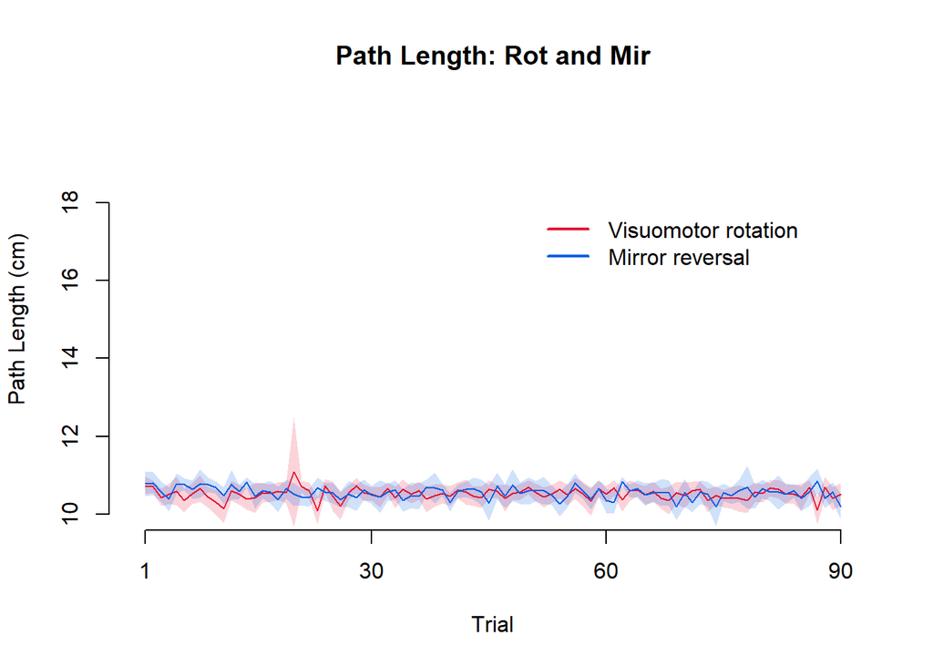

```r
plotPTypePathLength(group='instructed')
```

Interestingly, we find that there is less PL variability in mirror reversed reaches for instructed participants compared to those observed with noninstructed participants. This suggests that they used the instructions to move in an optimal manner towards the target. Similar to the other measures above, we conducted t-tests to compare PLs between the last block of aligned trials with the first and last blocks of rotation and mirror reversed training. We then compared PLs between the two perturbation types.

```r
PLt.test(group='instructed')
```

```
## Aligned (last block) compared to Rotation (first block):
##
##  Paired t-test
##
## data:  ALdat$compensation and ROTdat$compensation
## t = 0.49754, df = 15, p-value = 0.626
## alternative hypothesis: true mean difference is not equal to 0
## 95 percent confidence interval:
##  -0.1035788  0.1666597
## sample estimates:
## mean difference
##      0.03154043
##
## Effect Size - Cohen d:
## [1] 0.1643365
## Bayesian t-test Aligned (last block) compared to Rotation (first block):
## Bayes factor analysis
## --------------
## [1] Alt., r=0.707 : 0.365352 ±0%
##
## Against denominator:
##   Null, mu1-mu2 = 0
## ---
## Bayes factor type: BFindepSample, JZS
##
## Aligned (last block) compared to Mirror (first block):
##
##  Paired t-test
##
## data:  ALdat$compensation and MIRdat$compensation
## t = -1.3083, df = 15, p-value = 0.2104
## alternative hypothesis: true mean difference is not equal to 0
## 95 percent confidence interval:
##  -0.25508971  0.06103991
## sample estimates:
## mean difference
##      -0.0970249
##
## Effect Size - Cohen d:
## [1] 0.4543367
```

[output cut: 44 more lines]

```
## sample estimates:
## mean difference
##      0.08855025
##
## Effect Size - Cohen d:
## [1] 0.3965926
## Bayesian t-test Aligned (last block) compared to Mirror (last block):
## Bayes factor analysis
## --------------
## [1] Alt., r=0.707 : 0.5429388 ±0%
##
## Against denominator:
##   Null, mu1-mu2 = 0
## ---
## Bayes factor type: BFindepSample, JZS
```

```r
pathlengthPerturbANOVA(group='instructed')
```

```
## $ANOVA
##              Effect DFn DFd        F           p p<.05        ges
## 2       perturbtype   1  15 4.059351 0.062216098       0.06247162
## 3             block   2  30 1.888061 0.168916472       0.04353613
## 4 perturbtype:block   2  30 6.702051 0.003925159     * 0.02868146
##
## $`Mauchly's Test for Sphericity`
##              Effect         W          p p<.05
## 3             block 0.9524859 0.71122989
## 4 perturbtype:block 0.6704794 0.06091134
##
## $`Sphericity Corrections`
##              Effect       GGe       p[GG] p[GG]<.05       HFe       p[HF]
## 3             block 0.9546411 0.171121690           1.0904106 0.168916472
## 4 perturbtype:block 0.7521508 0.008875787         * 0.8176245 0.007147874
##   p[HF]<.05
## 3
## 4         *
```

```r
PLBayesANOVA(group='instructed')
```

```
## Bayes factor analysis
## --------------
## [1] perturbtype + participant                             : 4.964099  ±1.04%
## [2] block + participant                                   : 0.6308216 ±0.7%
## [3] perturbtype + block + participant                     : 3.689575  ±1.57%
## [4] perturbtype + block + perturbtype:block + participant : 1.906547  ±1.18%
##
## Against denominator:
##   compensation ~ participant
## ---
## Bayes factor type: BFlinearModel, JZS
##
## Inclusion Bayes Factors (Model Averaged)
##
##                   P(prior) P(posterior) Inclusion BF
## participant           1.00         1.00
## perturbtype           0.60         0.87         4.32
## block                 0.60         0.51        0.696
## block:perturbtype     0.20         0.16        0.742
##
## * Compared among: all models
## *    Priors odds: uniform-equal
```

We find a significant perturbation type by block interaction, but only in the frequentist test.

```r
PLPerturbComparisonsAllBlocksEffSize(group='instructed')
```

```
##  contrast                    estimate     SE df t.ratio p.value
##  Block1: MIR vs. Block2: MIR  -0.0128 0.0692 15  -0.185  1.0000
##  Block1: MIR vs. Block3: MIR   0.1856 0.0790 15   2.350  0.2300
##  Block1: ROT vs. Block2: ROT   0.1092 0.0898 15   1.216  1.0000
##  Block1: ROT vs. Block3: ROT   0.0861 0.0754 15   1.142  1.0000
##  Block1: ROT vs. MIR           0.1286 0.0714 15   1.801  0.6432
##  Block2: ROT vs. MIR           0.2505 0.0828 15   3.024  0.0598
##  Block3: ROT vs. MIR           0.0291 0.0734 15   0.396  1.0000
##
## P value adjustment: bonferroni method for 7 tests
##                      contrast  etasquared
## 1 Block1: MIR vs. Block2: MIR 0.002278355
## 2 Block1: MIR vs. Block3: MIR 0.269141772
## 3 Block1: ROT vs. Block2: ROT 0.089723709
## 4 Block1: ROT vs. Block3: ROT 0.079968756
## 5         Block1: ROT vs. MIR 0.177749702
## 6         Block2: ROT vs. MIR 0.378812974
## 7         Block3: ROT vs. MIR 0.010335440
```

Following up on the frequentist test does not reveal any effects. Thus, we conclude that path lengths do not differ across trial types and between perturbation types.

# Study 2: Online experiment results

The online experiment consisted of two sessions. In the first session, participants (N = 63) trained with the mirror reversal perturbation in a browser-based task, while using their dominant hand to control either their mouse or trackpad. They then returned for a second session (N = 48), where they immediately had to complete the same mirror reversed reaches, so that we may test for retention. We then tested for generalization by having participants complete mirror reversed reaches to different target locations across the workspace, and with their untrained/ non-dominant hand.

Target locations were either 5 degrees, 45 degrees, or 85 degrees away from a mirror axis placed along the vertical midline. We refer to these as near, middle, and far targets respectively.

## Session 1

The first session began with 45 trials of aligned reaches with the participants’ dominant hand. Then they switched to using their non-dominant hand to complete 21 trials of aligned reaches. We then instructed them to switch back to using their dominant hand to complete 90 mirror reversed trials. Finally, they completed 21 trials of washout trials using their trained/ dominant hand.

### Learning

We observe really fast learning in the online paradigm (see also supplementary R notebook), which is due to participants exploring the workspace during the very first trial. Regardless, participants learned to compensate for the mirror reversal in each of the target locations accordingly.

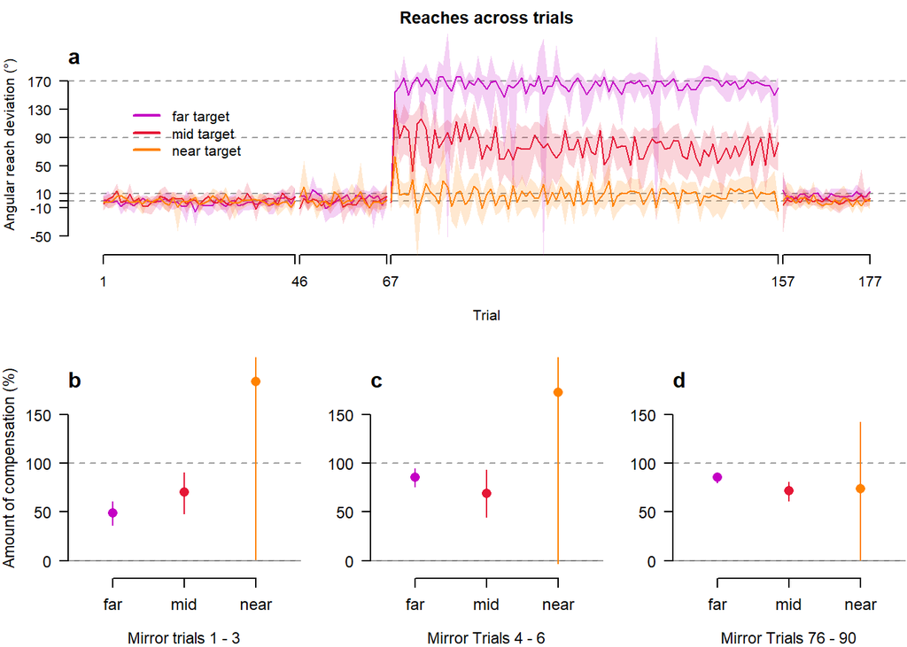

```r
plotBlockedMirCtrl()
```

Before comparing learning across the three target locations, we first tested whether reaching performance in aligned reaches differed depending on the hand used to control the cursor. Thus we took the aligned reaches from each hand, and compared the first, second, and last block of reaching trials (trials 1-9, 10-18, 37-45 for the dominant hand, trials 46-48, 49-51, 64-66 for the nondominant hand) to the three target locations. We conducted a 3x3x2 (target x block x hand) within-subjects ANOVA.

```r
alignedLearningANOVA2Hands()
```

```
## Comparing targets and blocks between trained and untrained hands:
## $ANOVA
##              Effect DFn DFd         F         p p<.05          ges
## 2            target   2 124 0.2179356 0.8044846       0.0004305633
## 3             block   2 124 1.3531164 0.2622224       0.0024565576
## 4              hand   1  62 1.9838470 0.1639809       0.0026447799
## 5      target:block   4 248 1.2672615 0.2834110       0.0043808665
## 6       target:hand   2 124 1.9789967 0.1425491       0.0039777107
## 7        block:hand   2 124 1.3071810 0.2742839       0.0015969121
## 8 target:block:hand   4 248 0.7323503 0.5706330       0.0023947652
##
## $`Mauchly's Test for Sphericity`
##              Effect         W            p p<.05
## 2            target 0.9897920 0.7312906822
## 3             block 0.9037101 0.0455920517     *
## 5      target:block 0.5974755 0.0002844163     *
## 6       target:hand 0.9901295 0.7389344283
## 7        block:hand 0.9614900 0.3018665755
## 8 target:block:hand 0.7066081 0.0127693436     *
##
## $`Sphericity Corrections`
##              Effect       GGe     p[GG] p[GG]<.05       HFe     p[HF] p[HF]<.05
## 2            target 0.9898951 0.8022947           1.0223789 0.8044846
## 3             block 0.9121675 0.2618553           0.9383619 0.2620144
## 5      target:block 0.8270634 0.2862176           0.8792547 0.2855044
## 6       target:hand 0.9902260 0.1430381           1.0227374 0.1425491
## 7        block:hand 0.9629180 0.2739438           0.9931696 0.2742274
## 8 target:block:hand 0.8525704 0.5501990           0.9082129 0.5582730
```

```r
alignedLearning2HandsBayesANOVA()
```

```
## Bayes factor analysis
## --------------
## [1] target + participant                                                                               : 0.01325636   ±1.65%
## [2] block + participant                                                                                : 0.04007914   ±0.79%
## [3] target + block + participant                                                                       : 0.0005144658 ±0.98%
## [4] target + block + target:block + participant                                                        : 1.114321e-05 ±1.33%
## [5] hand + participant                                                                                 : 0.292334     ±0.91%
## [6] target + hand + participant                                                                        : 0.003975711  ±5.63%
## [7] block + hand + participant                                                                         : 0.01185745   ±1.8%
## [8] target + block + hand + participant                                                                : 0.0001600222 ±2.58%
## [9] target + block + target:block + hand + participant                                                 : 3.553419e-06 ±3.29%
## [10] target + hand + target:hand + participant                                                         : 0.0006801341 ±2.92%
## [11] target + block + hand + target:hand + participant                                                 : 2.732007e-05 ±2.39%
## [12] target + block + target:block + hand + target:hand + participant                                  : 5.925693e-07 ±2.05%
## [13] block + hand + block:hand + participant                                                           : 0.0005504688 ±1.63%
## [14] target + block + hand + block:hand + participant                                                  : 7.266555e-06 ±2.67%
## [15] target + block + target:block + hand + block:hand + participant                                   : 1.708336e-07 ±4.4%
## [16] target + block + hand + target:hand + block:hand + participant                                    : 1.232762e-06 ±2.18%
## [17] target + block + target:block + hand + target:hand + block:hand + participant                     : 3.196293e-08 ±10.28%
## [18] target + block + target:block + hand + target:hand + block:hand + target:block:hand + participant : 6.683566e-10 ±3.01%
##
## Against denominator:
##   angdev ~ participant
## ---
## Bayes factor type: BFlinearModel, JZS
##
## Inclusion Bayes Factors (Model Averaged)
##
##                   P(prior) P(posterior) Inclusion BF
## participant           1.00         1.00
## target                0.74         0.01        0.005
## block                 0.74         0.04        0.015
## block:target          0.32     1.14e-05     2.46e-05
## hand                  0.74         0.23        0.105
## hand:target           0.32     5.20e-04        0.001
## block:hand            0.32     4.10e-04     8.89e-04
## block:hand:target     0.05     4.90e-10     8.82e-09
##
## * Compared among: all models
## *    Priors odds: uniform-equal
```

We do not find an effect for the hand used, suggesting that aligned reaching performance is not different regardless of which hand was used.

Next, given that we observe fast learning, we cannot fit the exponential function to this data and generate reliable measures of learning rate and learning asymptote. Instead, we compare reaching performance to the three target locations across the first, second, and last few blocks of training trials (trials 1-3, 4-6, 76-90). We conduct a 3x3 (target x block) within-subjects ANOVA. We converted the angular reach deviations to percentage of compensation, such that the three target locations will be comparable.

```r
mirrorANOVA()
```

```
## $ANOVA
##         Effect DFn DFd         F         p p<.05         ges
## 2       target   2 124 3.0295259 0.0519312       0.008910013
## 3        block   2 124 0.3898554 0.6779818       0.001475398
## 4 target:block   4 248 0.7498522 0.5589303       0.005797917
##
## $`Mauchly's Test for Sphericity`
##         Effect           W            p p<.05
## 2       target 0.081089137 5.288856e-34     *
## 3        block 0.788174290 7.030384e-04     *
## 4 target:block 0.001314326 1.719368e-80     *
##
## $`Sphericity Corrections`
##         Effect       GGe      p[GG] p[GG]<.05       HFe     p[HF] p[HF]<.05
## 2       target 0.5211289 0.08499643           0.5221834 0.0849105
## 3        block 0.8252012 0.63813105           0.8448718 0.6430256
## 4 target:block 0.4217775 0.45392147           0.4322788 0.4569101
```

```r
mirrorBayesANOVA()
```

```
## Bayes factor analysis
## --------------
## [1] target + participant                        : 0.2485678    ±4.56%
## [2] block + participant                         : 0.02967173   ±0.74%
## [3] target + block + participant                : 0.007056631  ±1.22%
## [4] target + block + target:block + participant : 0.0002120942 ±1.6%
##
## Against denominator:
##   percentcomp ~ participant
## ---
## Bayes factor type: BFlinearModel, JZS
##
## Inclusion Bayes Factors (Model Averaged)
##
##              P(prior) P(posterior) Inclusion BF
## participant      1.00         1.00
## target           0.60         0.20        0.166
## block            0.60         0.03        0.020
## block:target     0.20     1.65e-04     6.60e-04
##
## * Compared among: all models
## *    Priors odds: uniform-equal
```

We do not find any effects, suggesting that reaching performance did not differ across the the three target locations throughout training.

### Reach aftereffects

From the plot, we do not observe evidence of reach aftereffects in all targets. To quantify this, we compared the first two blocks of trials during washout (trials 1-3, 4-6) with aligned reaches to the three targets. We conducted a 3x3 (block x target) within-subjects ANOVA.

```r
RAETrainedTargetsANOVA()
```

```
## Comparing angular reach deviations during washout trials with aligned trials across targets and blocks, trained hand:
## $ANOVA
##         Effect DFn DFd         F           p p<.05          ges
## 2        block   2 124 5.5489808 0.004919479     * 0.0188621974
## 3       target   2 124 0.2323375 0.793022859       0.0009205765
## 4 block:target   4 248 0.5536739 0.696516136       0.0037747082
##
## $`Mauchly's Test for Sphericity`
##         Effect         W            p p<.05
## 2        block 0.8438785 5.643359e-03     *
## 3       target 0.9432319 1.682147e-01
## 4 block:target 0.5573588 5.277465e-05     *
##
## $`Sphericity Corrections`
##         Effect       GGe       p[GG] p[GG]<.05       HFe      p[HF] p[HF]<.05
## 2        block 0.8649610 0.007331719         * 0.8875473 0.00685751         *
## 3       target 0.9462814 0.780948587           0.9751826 0.78755341
## 4 block:target 0.8083289 0.659341405           0.8580494 0.66975796
```

```r
RAETrainedTargetsBayesANOVA()
```

```
## Bayes factor analysis
## --------------
## [1] target + participant                        : 0.02564791  ±1.37%
## [2] block + participant                         : 4.249054    ±1.16%
## [3] target + block + participant                : 0.1065248   ±1.17%
## [4] target + block + target:block + participant : 0.002013371 ±3.07%
##
## Against denominator:
##   angdev ~ participant
## ---
## Bayes factor type: BFlinearModel, JZS
##
## Inclusion Bayes Factors (Model Averaged)
##
##              P(prior) P(posterior) Inclusion BF
## participant      1.00         1.00
## target           0.60         0.02        0.017
## block            0.60         0.81         2.83
## block:target     0.20     3.74e-04        0.001
##
## * Compared among: all models
## *    Priors odds: uniform-equal
```

We find a main effect of block.

```r
RAETrainedTargetsComparisonsEffSize()
```

```
##  contrast                  estimate   SE df t.ratio p.value
##  Aligned vs. Washout_b1       11.81 3.25 62   3.639  0.0017
##  Aligned vs. Washout_b2        8.47 3.30 62   2.564  0.0384
##  Washout_b1 vs. Washout_b2    -3.34 4.32 62  -0.775  1.0000
##
## P value adjustment: bonferroni method for 3 tests
##                    contrast etasquared
## 1    Aligned vs. Washout_b1 0.17599701
## 2    Aligned vs. Washout_b2 0.09585021
## 3 Washout_b1 vs. Washout_b2 0.00958323
```

```r
RAETrainedTargetsBayesfollowup()
```

```
## Bayesian t-test aligned vs washout block 1:
## Bayes factor analysis
## --------------
## [1] Alt., r=0.707 : 87.01229 ±0%
##
## Against denominator:
##   Null, mu1-mu2 = 0
## ---
## Bayes factor type: BFindepSample, JZS
##
## Bayesian t-test aligned vs washout block 2:
## Bayes factor analysis
## --------------
## [1] Alt., r=0.707 : 3.095192 ±0.01%
##
## Against denominator:
##   Null, mu1-mu2 = 0
## ---
## Bayes factor type: BFindepSample, JZS
##
## Bayesian t-test washout block 1 vs washout block 2:
## Bayes factor analysis
## --------------
## [1] Alt., r=0.707 : 0.2464351 ±0.03%
##
## Against denominator:
##   Null, mu1-mu2 = 0
## ---
## Bayes factor type: BFindepSample, JZS
```

Follow up tests show that the aligned session differs from both first and second washout blocks, suggesting that aftereffects are present.

```r
RAETrainedTargetsComparisonMeans()
```

```
##  block    emmean    SE df lower.CL upper.CL
##  baseline  -3.14 0.975 62    -5.09     -1.2
##  first      8.66 3.003 62     2.66     14.7
##  second     5.32 3.246 62    -1.17     11.8
##
## Confidence level used: 0.95
```

However, these aftereffects are minimal (means of ~8 and 5 degrees for first and second blocks, respectively). Moreover, angular reach deviations do not differ between the first and second blocks of washout, suggesting that no de-adaptation is occurring.

### Movement analysis

We then repeated the same set of tests we conducted for learning and reach aftereffects, but with completion time and path length as the dependent variables.

#### Completion time

In the online study, the target for the next trial was shown as soon as the cursor acquired the start position. This meant that participants made movements towards the centre of the start position, before moving in the direction of the target again. As such, defining RTs would produce unreliable measures. We instead defined completion time, as the time elapsed between target onset and target acquisition (i.e., includes both RT plus MT).

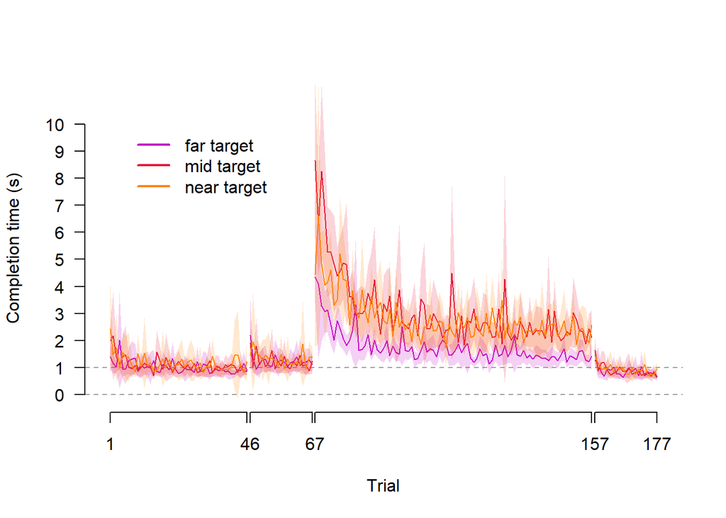

```r
plotCtrlMT()
```

We observe that completion time seems to be longer at the start of every trial type, and becomes faster as the trials progress. Therefore, in aligned reaches, we first test for an effect of target or block while participants used either their dominant or non-dominant hand. We conduct a 3x3 (target x block) within-subjects ANOVA for the dominant hand, and conduct the same test for aligned trials using the non-dominant hand.

```r
alignedMTANOVA()
```

```
## Movement time during aligned trials across targets and blocks, trained hand:
## $ANOVA
##         Effect DFn DFd          F            p p<.05          ges
## 2        block   2 124 13.9833711 3.339906e-06     * 0.0184311123
## 3       target   2 124  3.7807763 2.547693e-02     * 0.0039431677
## 4 block:target   4 248  0.4007115 8.080525e-01       0.0001096509
##
## $`Mauchly's Test for Sphericity`
##         Effect         W            p p<.05
## 2        block 0.3091451 2.818061e-16     *
## 3       target 0.2870943 2.949510e-17     *
## 4 block:target 0.6247809 8.159855e-04     *
##
## $`Sphericity Corrections`
##         Effect       GGe        p[GG] p[GG]<.05       HFe        p[HF]
## 2        block 0.5914168 0.0001673766         * 0.5962010 0.0001598296
## 3       target 0.5838033 0.0494976243         * 0.5881670 0.0491594253
## 4 block:target 0.8200657 0.7701889579           0.8713278 0.7819377433
##   p[HF]<.05
## 2         *
## 3         *
## 4
##
## Movement time during aligned trials across targets and blocks, untrained hand:
## $ANOVA
##         Effect DFn DFd         F          p p<.05          ges
## 2        block   2 124 6.2489955 0.00259607     * 0.0167569456
## 3       target   2 124 2.3304727 0.10149548       0.0018845990
## 4 block:target   4 248 0.2765287 0.89298574       0.0003957172
##
## $`Mauchly's Test for Sphericity`
##         Effect         W            p p<.05
## 2        block 0.4381320 1.172062e-11     *
## 3       target 0.9836857 6.055076e-01
## 4 block:target 0.2761175 4.668220e-13     *
##
## $`Sphericity Corrections`
##         Effect       GGe       p[GG] p[GG]<.05       HFe       p[HF] p[HF]<.05
## 2        block 0.6402590 0.009194215         * 0.6478368 0.008951399         *
## 3       target 0.9839476 0.102436849           1.0159347 0.101495479
## 4 block:target 0.5910539 0.794635028           0.6160126 0.803213183
```

```r
alignedMTBayesANOVA()
```

```
## Bayes factor analysis
## --------------
## [1] target + participant                        : 3.14329     ±0.84%
## [2] block + participant                         : 2111733988  ±1.8%
## [3] target + block + participant                : 11267765946 ±1.05%
## [4] target + block + target:block + participant : 97372484    ±1.61%
##
## Against denominator:
##   movementtime ~ participant
## ---
## Bayes factor type: BFlinearModel, JZS
##
## Inclusion Bayes Factors (Model Averaged)
##
##              P(prior) P(posterior) Inclusion BF
## participant      1.00         1.00
## target           0.60         0.84         3.59
## block            0.60         1.00     2.17e+09
## block:target     0.20     7.23e-03        0.029
##
## * Compared among: all models
## *    Priors odds: uniform-equalBayes factor analysis
## --------------
## [1] target + participant                        : 0.07656882 ±0.61%
## [2] block + participant                         : 7313.536   ±0.7%
## [3] target + block + participant                : 626.4187   ±2.28%
## [4] target + block + target:block + participant : 6.144099   ±2.54%
##
## Against denominator:
##   movementtime ~ participant
## ---
## Bayes factor type: BFlinearModel, JZS
##
## Inclusion Bayes Factors (Model Averaged)
##
##              P(prior) P(posterior) Inclusion BF
## participant      1.00         1.00
## target           0.60         0.08        0.058
## block            0.60         1.00     4.92e+03
## block:target     0.20     7.73e-04        0.003
##
## * Compared among: all models
## *    Priors odds: uniform-equal
```

We find main effects of target and block for the trained hand, and a main effect of block for the untrained hand. The effect of block is expected, given that completion time becomes faster as trials progress. We investigate the target effect in the trained hand further.

```r
trainedHandMTComparisonsEffSizeTargetEffect()
```

```
##  contrast     estimate     SE df t.ratio p.value
##  Far vs. Mid    0.0941 0.0278 62   3.378  0.0038
##  Far vs. Near   0.1778 0.0818 62   2.173  0.1008
##  Mid vs. Near   0.0837 0.0713 62   1.174  0.7346
##
## P value adjustment: bonferroni method for 3 tests
##       contrast etasquared
## 1  Far vs. Mid 0.15542100
## 2 Far vs. Near 0.07077687
## 3 Mid vs. Near 0.02174738
```

```r
trainedHandMTTargetEffectBayesfollowup()
```

```
## Bayesian t-test far vs mid target:
## Bayes factor analysis
## --------------
## [1] Alt., r=0.707 : 0.2229243 ±0.03%
##
## Against denominator:
##   Null, mu1-mu2 = 0
## ---
## Bayes factor type: BFindepSample, JZS
##
## Bayesian t-test far vs near target:
## Bayes factor analysis
## --------------
## [1] Alt., r=0.707 : 0.2637326 ±0.03%
##
## Against denominator:
##   Null, mu1-mu2 = 0
## ---
## Bayes factor type: BFindepSample, JZS
##
## Bayesian t-test mid vs near target:
## Bayes factor analysis
## --------------
## [1] Alt., r=0.707 : 0.2035166 ±0.04%
##
## Against denominator:
##   Null, mu1-mu2 = 0
## ---
## Bayes factor type: BFindepSample, JZS
```

Follow up frequentist tests show that the target effect is driven by a difference between the far and middle target. However, this difference is small and does not hold up in Bayesian t-tests. This may suggest that perhaps movements towards the far target are faster to initiate and execute.

Since we have confirmed these patterns within each hand’s aligned trials, we then test for an effect of hand used in completion time with a 3x3x2 (target x block x hand) within-subjects ANOVA.

```r
alignedMTANOVA2Hands()
```

```
## Comparing targets and blocks between trained and untrained hands:
## $ANOVA
##              Effect DFn DFd          F            p p<.05          ges
## 2            target   2 124  3.1793455 4.502617e-02     * 1.902889e-03
## 3             block   2 124 10.9050773 4.338131e-05     * 1.738211e-02
## 4              hand   1  62  8.3774637 5.238065e-03     * 6.158510e-03
## 5      target:block   4 248  0.2066594 9.345755e-01       1.018792e-04
## 6       target:hand   2 124  2.7305726 6.910332e-02       8.437125e-04
## 7        block:hand   2 124  0.1433789 8.665692e-01       7.573291e-05
## 8 target:block:hand   4 248  0.3831093 8.206260e-01       1.746956e-04
##
## $`Mauchly's Test for Sphericity`
##              Effect         W            p p<.05
## 2            target 0.6649390 3.934091e-06     *
## 3             block 0.2833814 1.983024e-17     *
## 5      target:block 0.2383686 8.055260e-15     *
## 6       target:hand 0.7857191 6.392243e-04     *
## 7        block:hand 0.6450537 1.558380e-06     *
## 8 target:block:hand 0.3877660 4.649175e-09     *
##
## $`Sphericity Corrections`
##              Effect       GGe        p[GG] p[GG]<.05       HFe        p[HF]
## 2            target 0.7490294 0.0601965745           0.7634276 0.0592095729
## 3             block 0.5825406 0.0008758157         * 0.5868350 0.0008489665
## 5      target:block 0.6141871 0.8554825790           0.6414461 0.8637610904
## 6       target:hand 0.8235327 0.0801469054           0.8430834 0.0788517477
## 7        block:hand 0.7380366 0.8016187696           0.7517078 0.8058280661
## 8 target:block:hand 0.6467472 0.7355183318           0.6773781 0.7448918107
##   p[HF]<.05
## 2
## 3         *
## 5
## 6
## 7
## 8
```

```r
alignedMT2HandsBayesANOVA()
```

```
## Bayes factor analysis
## --------------
## [1] target + participant                                                                               : 0.246656     ±4%
## [2] block + participant                                                                                : 71142522934  ±0.95%
## [3] target + block + participant                                                                       : 19597508215  ±3.55%
## [4] target + block + target:block + participant                                                        : 53179574     ±3.28%
## [5] hand + participant                                                                                 : 1887.306     ±0.9%
## [6] target + hand + participant                                                                        : 443.2794     ±1.1%
## [7] block + hand + participant                                                                         : 2.426425e+14 ±1.3%
## [8] target + block + hand + participant                                                                : 7.19725e+13  ±3.21%
## [9] target + block + target:block + hand + participant                                                 : 195565615524 ±5.1%
## [10] target + hand + target:hand + participant                                                         : 35.9069      ±3.6%
## [11] target + block + hand + target:hand + participant                                                 : 6.12851e+12  ±3.56%
## [12] target + block + target:block + hand + target:hand + participant                                  : 15725893361  ±2.27%
## [13] block + hand + block:hand + participant                                                           : 6.064108e+12 ±7.46%
## [14] target + block + hand + block:hand + participant                                                  : 1.833401e+12 ±11.52%
## [15] target + block + target:block + hand + block:hand + participant                                   : 4245878339   ±2.24%
## [16] target + block + hand + target:hand + block:hand + participant                                    : 137834384687 ±2.61%
## [17] target + block + target:block + hand + target:hand + block:hand + participant                     : 352808925    ±2.22%
## [18] target + block + target:block + hand + target:hand + block:hand + target:block:hand + participant : 3502132      ±3.98%
##
## Against denominator:
##   movementtime ~ participant
## ---
## Bayes factor type: BFlinearModel, JZS
##
## Inclusion Bayes Factors (Model Averaged)
##
##                   P(prior) P(posterior) Inclusion BF
## participant           1.00         1.00
## target                0.74         0.24        0.115
## block                 0.74         1.00     4.96e+10
## block:target          0.32     6.56e-04        0.001
## hand                  0.74         1.00     1.29e+03
## hand:target           0.32         0.02        0.042
## block:hand            0.32         0.02        0.054
## block:hand:target     0.05     1.06e-08     1.92e-07
##
## * Compared among: all models
## *    Priors odds: uniform-equal
```

We find a main effect of hand.

```r
MTComparisonsHandEffect()
```

```
##
##  Paired t-test
##
## data:  trained$movementtime and untrained$movementtime
## t = -2.8944, df = 62, p-value = 0.002619
## alternative hypothesis: true mean difference is less than 0
## 95 percent confidence interval:
##         -Inf -0.08422589
## sample estimates:
## mean difference
##       -0.199074
##
## Bayesian t-test (trained hand vs. untrained hand):
## Bayes factor analysis
## --------------
## [1] Alt., r=0.707 -Inf<d<0 : 321.9046 ±0%
##
## Against denominator:
##   Alternative, r = 0.707106781186548, mu =/= 0 !(-Inf<d<0)
## ---
## Bayes factor type: BFoneSample, JZS
```

Follow-up tests suggest that completion time in the trained (dominant) hand is faster than in the untrained (nondominant) hand.

Next, we conduct a 3x3 (target x block) within-subjects ANOVA to test for completion time effects during the mirror reversed trials.

```r
mirrorMTANOVA()
```

```
## $ANOVA
##         Effect DFn DFd         F            p p<.05        ges
## 2       target   2 124 24.240009 1.301187e-09     * 0.06931910
## 3        block   2 124 41.536873 1.557371e-14     * 0.13156353
## 4 target:block   4 248  3.768315 5.385664e-03     * 0.01756984
##
## $`Mauchly's Test for Sphericity`
##         Effect         W            p p<.05
## 2       target 0.9744759 4.544840e-01
## 3        block 0.6582257 2.886900e-06     *
## 4 target:block 0.2727198 3.320161e-13     *
##
## $`Sphericity Corrections`
##         Effect       GGe        p[GG] p[GG]<.05       HFe        p[HF]
## 2       target 0.9751112 1.985595e-09         * 1.0063651 1.301187e-09
## 3        block 0.7452818 1.957267e-11         * 0.7594312 1.315793e-11
## 4 target:block 0.5725432 2.047303e-02         * 0.5957181 1.902400e-02
##   p[HF]<.05
## 2         *
## 3         *
## 4         *
```

```r
mirrorMTBayesANOVA()
```

```
## Bayes factor analysis
## --------------
## [1] target + participant                        : 7679421      ±0.71%
## [2] block + participant                         : 5.237651e+16 ±2.73%
## [3] target + block + participant                : 1.666676e+25 ±0.99%
## [4] target + block + target:block + participant : 2.225768e+25 ±1.4%
##
## Against denominator:
##   movementtime ~ participant
## ---
## Bayes factor type: BFlinearModel, JZS
##
## Inclusion Bayes Factors (Model Averaged)
##
##              P(prior) P(posterior) Inclusion BF
## participant      1.00         1.00
## target           0.60         1.00     4.95e+08
## block            0.60         1.00     3.38e+18
## block:target     0.20         0.57         5.34
##
## * Compared among: all models
## *    Priors odds: uniform-equal
```

We find a significant block by target interaction.

```r
mirrorMTComparisonsEffSize()
```

```
##  contrast                 estimate    SE df t.ratio p.value
##  1st block: Far vs. Mid    3.77155 0.684 62   5.516  <.0001
##  1st block: Far vs. Near   1.35750 0.858 62   1.581  1.0000
##  1st block: Mid vs. Near  -2.41405 1.024 62  -2.357  0.1942
##  2nd block: Far vs. Mid    2.91477 0.497 62   5.866  <.0001
##  2nd block: Far vs. Near   1.35358 0.497 62   2.725  0.0752
##  2nd block: Mid vs. Near  -1.56119 0.538 62  -2.903  0.0460
##  last block: Far vs. Mid   1.00064 0.149 62   6.709  <.0001
##  last block: Far vs. Near  0.99615 0.152 62   6.543  <.0001
##  last block: Mid vs. Near -0.00449 0.145 62  -0.031  1.0000
##
## P value adjustment: bonferroni method for 9 tests
##                   contrast   etasquared
## 1   1st block: Far vs. Mid 3.291755e-01
## 2  1st block: Far vs. Near 3.876890e-02
## 3  1st block: Mid vs. Near 8.225596e-02
## 4   2nd block: Far vs. Mid 3.569403e-01
## 5  2nd block: Far vs. Near 1.069388e-01
## 6  2nd block: Mid vs. Near 1.196496e-01
## 7  last block: Far vs. Mid 4.206092e-01
## 8 last block: Far vs. Near 4.084704e-01
## 9 last block: Mid vs. Near 1.534659e-05
```

```r
mirrorMTBayesfollowup()
```

```
## FIRST BLOCK:
## Bayesian t-test far vs mid target:
## Bayes factor analysis
## --------------
## [1] Alt., r=0.707 : 452.3834 ±0%
##
## Against denominator:
##   Null, mu1-mu2 = 0
## ---
## Bayes factor type: BFindepSample, JZS
##
## Bayesian t-test far vs near target:
## Bayes factor analysis
## --------------
## [1] Alt., r=0.707 : 0.4475591 ±0.02%
##
## Against denominator:
##   Null, mu1-mu2 = 0
## ---
## Bayes factor type: BFindepSample, JZS
##
## Bayesian t-test mid vs near target:
## Bayes factor analysis
## --------------
## [1] Alt., r=0.707 : 1.501172 ±0.01%
##
## Against denominator:
##   Null, mu1-mu2 = 0
## ---
## Bayes factor type: BFindepSample, JZS
##
## SECOND BLOCK:
## Bayesian t-test far vs mid target:
## Bayes factor analysis
## --------------
## [1] Alt., r=0.707 : 12111.64 ±0%
##
## Against denominator:
##   Null, mu1-mu2 = 0
## ---
```

[output cut: 37 more lines]

```
##
## Against denominator:
##   Null, mu1-mu2 = 0
## ---
## Bayes factor type: BFindepSample, JZS
##
## Bayesian t-test mid vs near target:
## Bayes factor analysis
## --------------
## [1] Alt., r=0.707 : 0.1901957 ±0.04%
##
## Against denominator:
##   Null, mu1-mu2 = 0
## ---
## Bayes factor type: BFindepSample, JZS
```

Follow-up tests show faster completion times for the far target compared to the middle target across all three blocks. The far target is also faster than the near target for the last block. These results suggest that movement initiation and execution towards the far target is faster than the other two targets.

For washout trials, we first conduct a 3x2 (target x first and second block) within-subject ANOVA, to test for any effects across target locations.

```r
RAEMTANOVA()
```

```
## Movement time during washout trials across targets and blocks, trained hand:
## $ANOVA
##         Effect DFn DFd          F            p p<.05          ges
## 2        block   1  62 49.1623291 2.053179e-09     * 0.0239235714
## 3       target   2 124  4.2110240 1.700614e-02     * 0.0068722931
## 4 block:target   2 124  0.1097604 8.961358e-01       0.0001621676
##
## $`Mauchly's Test for Sphericity`
##         Effect         W         p p<.05
## 3       target 0.9978041 0.9351505
## 4 block:target 0.9377759 0.1409358
##
## $`Sphericity Corrections`
##         Effect       GGe     p[GG] p[GG]<.05       HFe      p[HF] p[HF]<.05
## 3       target 0.9978089 0.0170779         * 1.0309574 0.01700614         *
## 4 block:target 0.9414209 0.8851467           0.9699314 0.89064933
```

```r
RAEMTBayesANOVA()
```

```
## Bayes factor analysis
## --------------
## [1] target + participant                        : 1.559216 ±0.93%
## [2] block + participant                         : 513746.1 ±2.72%
## [3] target + block + participant                : 1205489  ±3.02%
## [4] target + block + target:block + participant : 68675.65 ±1.64%
##
## Against denominator:
##   movementtime ~ participant
## ---
## Bayes factor type: BFlinearModel, JZS
##
## Inclusion Bayes Factors (Model Averaged)
##
##              P(prior) P(posterior) Inclusion BF
## participant      1.00         1.00
## target           0.60         0.71         1.65
## block            0.60         1.00     4.66e+05
## block:target     0.20         0.04        0.160
##
## * Compared among: all models
## *    Priors odds: uniform-equal
```

We find main effects of target and block, but no interaction.

```r
RAEMTComparisonsEffSizeTargetEffect()
```

```
##  contrast     estimate     SE df t.ratio p.value
##  Far vs. Mid    0.0957 0.0509 62   1.879  0.1947
##  Far vs. Near   0.1468 0.0506 62   2.901  0.0154
##  Mid vs. Near   0.0511 0.0525 62   0.973  1.0000
##
## P value adjustment: bonferroni method for 3 tests
##       contrast etasquared
## 1  Far vs. Mid 0.05389934
## 2 Far vs. Near 0.11950706
## 3 Mid vs. Near 0.01504785
```

```r
RAEMTTargetEffectBayesfollowup()
```

```
## Bayesian t-test far vs mid target:
## Bayes factor analysis
## --------------
## [1] Alt., r=0.707 : 0.2486001 ±0.03%
##
## Against denominator:
##   Null, mu1-mu2 = 0
## ---
## Bayes factor type: BFindepSample, JZS
##
## Bayesian t-test far vs near target:
## Bayes factor analysis
## --------------
## [1] Alt., r=0.707 : 0.3606759 ±0.03%
##
## Against denominator:
##   Null, mu1-mu2 = 0
## ---
## Bayes factor type: BFindepSample, JZS
##
## Bayesian t-test mid vs near target:
## Bayes factor analysis
## --------------
## [1] Alt., r=0.707 : 0.2061641 ±0.04%
##
## Against denominator:
##   Null, mu1-mu2 = 0
## ---
## Bayes factor type: BFindepSample, JZS
```

Follow-up tests show that the target effect is driven by a difference between the far and near targets, but these differences are small and do not hold up in Bayesian tests.

Now that we have confirmed these patterns, we can now compare washout trials with those in aligned to test for completion time effects between aligned and washout trials. We conduct a 3x3 (target x block) within-subjects ANOVA, where block considers the aligned trials, first, and second block of washout trials.

```r
RAEMTTrainedTargetsANOVA()
```

```
## Comparing movement times during washout trials with aligned trials across targets and blocks, trained hand:
## $ANOVA
##         Effect DFn DFd          F            p p<.05          ges
## 2        block   2 124 9.93029285 9.994277e-05     * 0.0140440457
## 3       target   2 124 9.07320678 2.101446e-04     * 0.0065829384
## 4 block:target   4 248 0.09110735 9.851931e-01       0.0001319642
##
## $`Mauchly's Test for Sphericity`
##         Effect         W            p p<.05
## 2        block 0.6351112 9.703270e-07     *
## 3       target 0.9718037 4.179711e-01
## 4 block:target 0.3307473 6.467021e-11     *
##
## $`Sphericity Corrections`
##         Effect       GGe        p[GG] p[GG]<.05       HFe        p[HF]
## 2        block 0.7326604 0.0005554876         * 0.7459791 0.0005097983
## 3       target 0.9725770 0.0002458168         * 1.0036217 0.0002101446
## 4 block:target 0.6347400 0.9470049475           0.6641091 0.9523221858
##   p[HF]<.05
## 2         *
## 3         *
## 4
```

```r
RAEMTTrainedTargetsBayesANOVA()
```

```
## Bayes factor analysis
## --------------
## [1] target + participant                        : 13.71731 ±0.69%
## [2] block + participant                         : 34162.48 ±0.7%
## [3] target + block + participant                : 709793.7 ±1.15%
## [4] target + block + target:block + participant : 6382.138 ±8.57%
##
## Against denominator:
##   movementtime ~ participant
## ---
## Bayes factor type: BFlinearModel, JZS
##
## Inclusion Bayes Factors (Model Averaged)
##
##              P(prior) P(posterior) Inclusion BF
## participant      1.00         1.00
## target           0.60         0.95        13.98
## block            0.60         1.00     3.40e+04
## block:target     0.20     8.51e-03        0.034
##
## * Compared among: all models
## *    Priors odds: uniform-equal
```

We find main effects of block and target, but no interaction. We then conduct follow-up tests on the block effect, regardless of target location.

```r
RAEMTTrainedTargetsComparisonsEffSize()
```

```
##  contrast                  estimate     SE df t.ratio p.value
##  Aligned vs. Washout_b1      0.0876 0.0598 62   1.466  0.4428
##  Aligned vs. Washout_b2     -0.1414 0.0586 62  -2.414  0.0562
##  Washout_b1 vs. Washout_b2  -0.2291 0.0327 62  -7.012  <.0001
##
## P value adjustment: bonferroni method for 3 tests
##                    contrast etasquared
## 1    Aligned vs. Washout_b1  0.0335211
## 2    Aligned vs. Washout_b2  0.0859177
## 3 Washout_b1 vs. Washout_b2  0.4422571
```

```r
RAEMTTrainedTargetsBlockEffectBayesfollowup()
```

```
## Bayesian t-test aligned vs washout block 1:
## Bayes factor analysis
## --------------
## [1] Alt., r=0.707 : 0.2259262 ±0.03%
##
## Against denominator:
##   Null, mu1-mu2 = 0
## ---
## Bayes factor type: BFindepSample, JZS
##
## Bayesian t-test aligned vs washout block 2:
## Bayes factor analysis
## --------------
## [1] Alt., r=0.707 : 0.3130464 ±0.03%
##
## Against denominator:
##   Null, mu1-mu2 = 0
## ---
## Bayes factor type: BFindepSample, JZS
##
## Bayesian t-test washout block 1 vs washout block 2:
## Bayes factor analysis
## --------------
## [1] Alt., r=0.707 : 1.036413 ±0.01%
##
## Against denominator:
##   Null, mu1-mu2 = 0
## ---
## Bayes factor type: BFindepSample, JZS
```

We find that the main effect of block is driven by a difference between the two blocks during washout, given that completion time is faster as trials progress. Overall, despite observing very small aftereffects, completion time during washout trials do not differ from completion times during aligned reaches.